# Unsupervised tools

María Ángeles Magro Garrote

2022

## An insight of Twitch

Twitch is an **online platform** who allows people stream on live. Although the focus of it tends to put on video games, there is a huge variety of categories such as just-chatting or sports. Due to this, Twitch gathers **31 million people** each day. What is more, the most viewed streamers make a big quantity of money due to adds, subscriptions and donations.

Taking all this into account, the goal of this project is to analyse a dataset containing information of the top 1000 streamers of Twitch created by **Aayush Mishra** in order to get some conclusions from it. This data set contain information from 2020.

The questions that will be answered (among others) are:

- Does the language they stream in affects the views of the stream? Or being partnered?
- Does having a peak of viewers affect your channel?
- Does having a lot of viewers impact your followers number?

All in all, **what makes a streamer great?**

Before starting the analysis, all the libraries needed will be loaded.

```r
rm(list=ls())
library(VIM)
library(mice)
library(tidyverse)
# ggplots side by side (grid.arrange)
library(gridExtra)
# ggplot2-based visualization of correlations
library(GGally)
# ggplot2-based visualization of pca
library(factoextra)
library(lubridate)
#only this for getsymbols
library(quantmod)
library(mclust)
library(cluster)
library(kernlab)
```

## 1. Data preprocessing

First, we read the data.

```r
data = read.csv("twitchdata-update.csv", header = TRUE, sep = ",")

# shortening the long variable names
colnames(data)[colnames(data) == "Watch.time.Minutes."] ="Watch.time.min"
colnames(data)[colnames(data) == "Stream.time.minutes."] ="Stream.time.min"

head(data)
```

```
##     Channel Watch.time.min Stream.time.min Peak.viewers Average.viewers
## 1     xQcOW     6196161750          215250       222720           27716
## 2  summit1g     6091677300          211845       310998           25610
## 3    Gaules     5644590915          515280       387315           10976
## 4  ESL_CSGO     3970318140          517740       300575            7714
## 5      Tfue     3671000070          123660       285644           29602
## 6 Asmongold     3668799075           82260       263720           42414
##   Followers Followers.gained Views.gained Partnered Mature   Language
## 1   3246298          1734810     93036735      True  False    English
## 2   5310163          1370184     89705964      True  False    English
## 3   1767635          1023779    102611607      True   True Portuguese
## 4   3944850           703986    106546942      True  False    English
## 5   8938903          2068424     78998587      True  False    English
## 6   1563438           554201     61715781      True  False    English
```

```r
# number of streamers in the data set
nrow(data)
```

```
## [1] 1000
```

The data set is ordered in a descending way, using Watch.Time.Min variable.

Before continuing, it must be clarify the meaning of each variable:

- **Channel**: name of the streamer
- **Watch.time.min**: time (min) that streamer has been watch in total.
- **Stream.time.min**: time (min) that streamer has streamed.
- **Peak.viewers**: highest viewers at the same time of the steamer.
- **Average.viewers**: the mean of viewers the streamer has.
- **Followers**: followers that streamer has.
- **Followers.gained**: new followers obtained by the streamer.
- **Views.gained**: new views obtained by the streamer.
- **Partnered**: if the streamer is partnered.
- **Mature**: if the category of the stream is +18 or not. +18 streaming may contain nudity, violence, etc… (F.ex: in videogames)
- **Language**: language spoken in the streamings.

*(Note that a viewer can watch a stream without being a follower)*  
*(Note that it is being referred to followers and not subscribers)*

Now, it must be checked the the missing values of the variables.

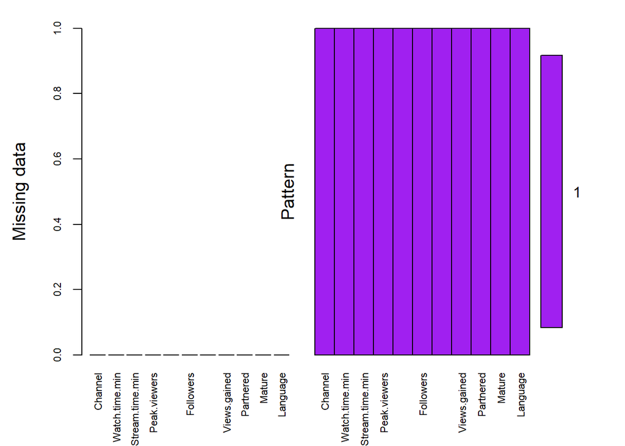

```
##
##  Variables sorted by number of missings:
##          Variable Count
##           Channel     0
##    Watch.time.min     0
##   Stream.time.min     0
##      Peak.viewers     0
##   Average.viewers     0
##         Followers     0
##  Followers.gained     0
##      Views.gained     0
##         Partnered     0
##            Mature     0
##          Language     0
```

```r
# checking missing values
aggr(data, numbers = TRUE, sortVars = TRUE, labels = names(data), cex.axis = .7, gap = 1, ylab= c('Missing data','Pattern'), col = c("purple", "red", "orange"))
```

```r
# checking for duplicated data
sum(duplicated(data))
```

```
## [1] 0
```

No missing or duplicated data is found.  
All the variables may give us some relevant information but the one containing the names of the streamers so it is erased, but first it will be saved for later analysis. Also, some transformations can be done to the Boolean variables.

```r
# eliminating irrelevant information
# before deleting the column, saving it for later.
names = data[, 1]
data = data %>% select(-c(Channel))

# there are two Boolean variables that can be
# transformed to numbers (Partnered and Mature).

data$Partnered=factor(data$Partnered, levels=
                           c("False","True"), labels=c(1,2))
data$Mature=factor(data$Mature, levels=
                        c("False","True"), labels=c(1,2))

# converting everything to numeric but the language variable.
for(i in 1:9) {
  data[,i] <- as.numeric(as.numeric(data[,i]))
}

# our data set now is:
head(data)
```

```
##   Watch.time.min Stream.time.min Peak.viewers Average.viewers Followers
## 1     6196161750          215250       222720           27716   3246298
## 2     6091677300          211845       310998           25610   5310163
## 3     5644590915          515280       387315           10976   1767635
## 4     3970318140          517740       300575            7714   3944850
## 5     3671000070          123660       285644           29602   8938903
## 6     3668799075           82260       263720           42414   1563438
##   Followers.gained Views.gained Partnered Mature   Language
## 1          1734810     93036735         2      1    English
## 2          1370184     89705964         2      1    English
## 3          1023779    102611607         2      2 Portuguese
## 4           703986    106546942         2      1    English
## 5          2068424     78998587         2      1    English
## 6           554201     61715781         2      1    English
```

Now, the outliers must be check. It has been decided to study the outliers of Watch.time.min because it is the one chosen to order top 1000 streamers, **NOT** because it is our target variable. Remember it is being tried to answer to the question: what makes a streamer great?

```r
mu <- mean(data$Watch.time.min)
sigma <- sd(data$Watch.time.min)

sum(data$Watch.time.min < mu - 3*sigma | data$Watch.time.min > mu + 3*sigma)
```

```
## [1] 18
```

```r
QI <- quantile(data$Watch.time.min, 0.25)
QS <- quantile(data$Watch.time.min, 0.75)
IQR = QS-QI

sum(data$Watch.time.min < QI - 1.5*IQR | data$Watch.time.min > QS + 1.5*IQR)
```

```
## [1] 107
```

Despite this, it has been decided **NOT** to eliminate the outliers because the purpose of this analysis is to study top 1000 streamers and due to this, erasing them would lead us to a huge loss of information of the highest watch people.

Furthermore, to check this:

```r
mean1 = mean(data$Watch.time.min[which(data$Watch.time.min < mu - 3*sigma | data$Watch.time.min > mu + 3*sigma)]);mean1
```

```
## [1] 3442450547
```

```r
mean2=mean(data$Watch.time.min);mean2
```

```
## [1] 418427930
```

```r
mean1>mean2
```

```
## [1] TRUE
```

So, the mean of Watch.time.min of the outliers is way more bigger than the mean of all the dataset. So, erasing outliers would give us losing information of the highest watched streamers, which would collide with the goal of our study. That is why it has been decided not to erase it.

Before continuing, some techniques that will be used may require only having numeric variables, which lead us to create another dataset without the language variable.

```r
# creating a new data set with only the numeric variables.
data.num = data[1:9]
# languages will be saved as names for using it later.
languages = data[,10]
# the numeric data set is:
head(data.num)
```

```
##   Watch.time.min Stream.time.min Peak.viewers Average.viewers Followers
## 1     6196161750          215250       222720           27716   3246298
## 2     6091677300          211845       310998           25610   5310163
## 3     5644590915          515280       387315           10976   1767635
## 4     3970318140          517740       300575            7714   3944850
## 5     3671000070          123660       285644           29602   8938903
## 6     3668799075           82260       263720           42414   1563438
##   Followers.gained Views.gained Partnered Mature
## 1          1734810     93036735         2      1
## 2          1370184     89705964         2      1
## 3          1023779    102611607         2      2
## 4           703986    106546942         2      1
## 5          2068424     78998587         2      1
## 6           554201     61715781         2      1
```

Also, it must be studied if the data set needs scaling.

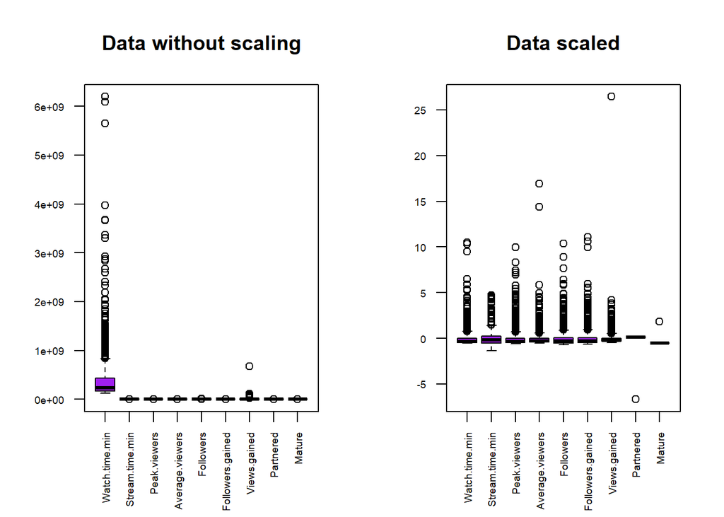

```r
# comparing  our data with the version scaled.
par(mfrow=c(1,2))
boxplot(data.num, las=2, col="purple", main ="Data without scaling", cex.axis = 0.6)
boxplot(scale(data.num), las=2, col="purple", main = "Data scaled", cex.axis = 0.6)
```

```r
# scaling the data set to work with smaller values.
for(i in 1:9) {
  data.num[,i] <- scale(data[,i])
}
```

## 2. Insights before using tools

Before strting with unsupervised learning, a general study of our data set is done.  
First, it is going to be check the correlation coefficient among all the variables.

```r
R = cor(data.num);R
```

```
##                  Watch.time.min Stream.time.min Peak.viewers Average.viewers
## Watch.time.min       1.00000000     0.150587901   0.58279665     0.476165001
## Stream.time.min      0.15058790     1.000000000  -0.11954029    -0.249247788
## Peak.viewers         0.58279665    -0.119540289   1.00000000     0.682637258
## Average.viewers      0.47616500    -0.249247788   0.68263726     1.000000000
## Followers            0.62023388    -0.091298506   0.53252932     0.428303225
## Followers.gained     0.51464756    -0.158164785   0.47041471     0.420097365
## Views.gained         0.52986201     0.064370026   0.29806263     0.250348872
## Partnered            0.03825803    -0.007073297   0.02811197    -0.008982709
## Mature              -0.04319701     0.044977672  -0.08275037    -0.081647925
##                    Followers Followers.gained Views.gained     Partnered
## Watch.time.min    0.62023388       0.51464756   0.52986201  0.0382580317
## Stream.time.min  -0.09129851      -0.15816479   0.06437003 -0.0070732973
## Peak.viewers      0.53252932       0.47041471   0.29806263  0.0281119695
## Average.viewers   0.42830322       0.42009736   0.25034887 -0.0089827088
## Followers         1.00000000       0.71561846   0.27646651  0.0444181077
## Followers.gained  0.71561846       1.00000000   0.24429687  0.0274650925
## Views.gained      0.27646651       0.24429687   1.00000000 -0.0353131120
## Partnered         0.04441811       0.02746509  -0.03531311  1.0000000000
## Mature           -0.08852078      -0.09300130  -0.08811931  0.0009719887
##                         Mature
## Watch.time.min   -0.0431970145
## Stream.time.min   0.0449776716
## Peak.viewers     -0.0827503690
## Average.viewers  -0.0816479254
## Followers        -0.0885207813
## Followers.gained -0.0930012960
## Views.gained     -0.0881193097
## Partnered         0.0009719887
## Mature            1.0000000000
```

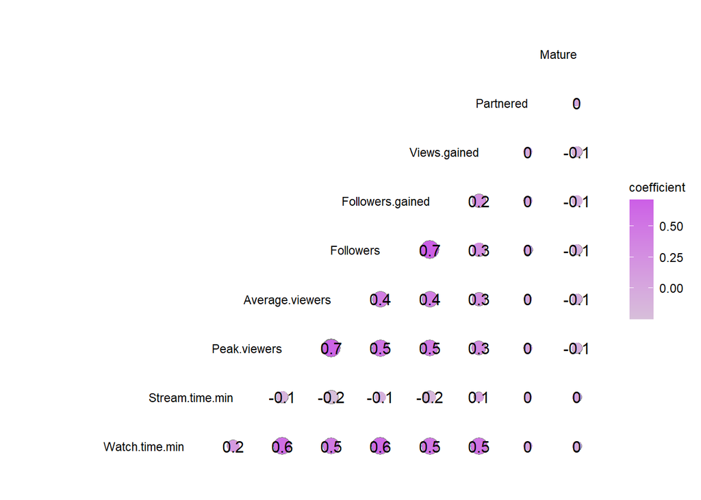

```r
# better to plot it (more visual)
ggcorr(data.num, label = T, geom = "circle", hjust= 1, size = 3, layout.exp = 3) + scale_color_gradient(low = "#D7BFDA", high = "#CC5FE6")
```

It is observed that:

- There are **not negative-linear** correlated variables.
- The most **positive-linear correlated but obvious** are: followers with followers.gained, peak.viewers with average.viewers
- **Other high positive correlated** which provide us useful information: watch.time.min with peak.viewers, watch.time.min with followers.
- **Weak positive liner** correlated: peak.viewers with followers, peak.viewers with followers.gained, watch.time.min with average.viewers, watch.time.min with followers.gained, watch.time.min with views.gained.

From this information, we can plot several images which can provide us useful insights about our dataset.

### A. Average.viewers and Mature (by Language)

Although language is not a numeric variable and no correlation coefficients are obtained, it may be worth analyzing it.

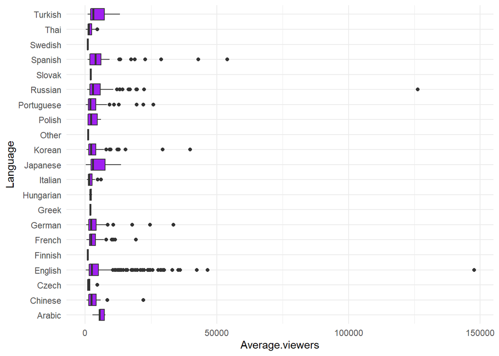

```r
ggplot(data) +
  aes(x = Average.viewers, y = Language) +
  geom_boxplot(fill = "purple") +
  theme_minimal()
```

It seems that there are some languages that have more viewers than others. It is going to be collected the information of viewers per language separated by non-Mature or Mature content.

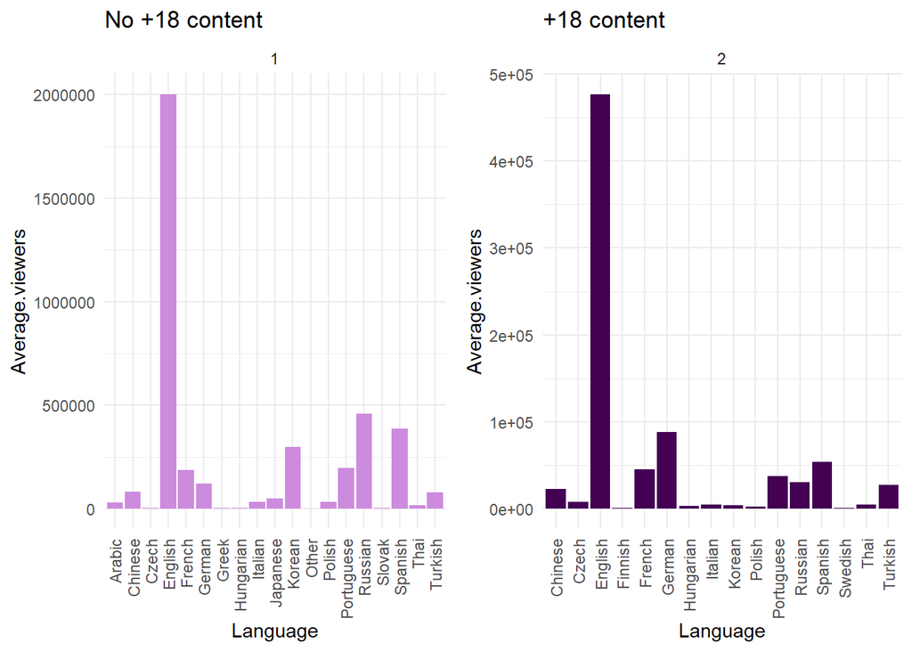

```r
# using subset to separate between mature and not mature content.
ggplot1 = ggplot(subset(data, Mature == 1)) +
  aes(x = Language, y = Average.viewers) +
  geom_col(fill = "#CD8BDD") +
  theme_minimal() +
  facet_wrap(vars(Mature)) +
  theme(axis.text.x = element_text(angle = 90, vjust = 0.5,
                                   hjust=1)) +
  labs(title = "No +18 content")

ggplot2 = ggplot(subset(data, Mature == 2)) +
  aes(x = Language, y = Average.viewers) +
  geom_col(fill = "#440154") +
  theme_minimal() +
  facet_wrap(vars(Mature)) +
  theme(axis.text.x = element_text(angle = 90, vjust = 0.5,   hjust=1)) +
  labs(title = "+18 content")

grid.arrange(ggplot1, ggplot2, ncol = 2)
```

*Note that the y scale of both graphs is different*

*Note that there are several languages that ggplot does not show due to its low quantity of viewers*

It is noticed that there are less viewers for +18 content than for non-matured content.

Do all countries have more viewers of Non-Mature content than Mature content?

```r
list.ratio = list()
list.languages = unique(data$Language)

# analyzing all languages and creating ratios. If ratio < 1: more Mature content views. If ratio > 1: more Non-Mature content.

# it will be used the notation created before: if Mature == 1 it means the content is not Mature. It Mature == 2, it is Mature content.

for(i in 1:length(list.languages)) {
  # using the list of languages, we will go language by language.
  subset = subset(data, Language == list.languages[i])

  # once we have all the data from that language, the sum of all the   viewers of non-mature content is going to be divided by the views   of mature content.

  division = sum(subset$Views.gained[which(subset$Mature==1)])        /sum(subset$Views.gained[which(subset$Mature==2)])

  # if the ratio is smaller than 1, it is saved.
  if (division < 1){
    list.ratio = c(list.ratio, list.languages[i])
    list.ratio = c(list.ratio, division)
  }
}

# the languages obtained are displayed:
list.ratio
```

```
## [[1]]
## [1] "Czech"
##
## [[2]]
## [1] 0.8398974
##
## [[3]]
## [1] "Hungarian"
##
## [[4]]
## [1] 0.7283187
##
## [[5]]
## [1] "Finnish"
##
## [[6]]
## [1] 0
##
## [[7]]
## [1] "Swedish"
##
## [[8]]
## [1] 0
```

It is obtained 4 languages that give more 18+ content than non-matured content: Czech, Hungarian, Finnish and Swedish. The last two mentioned with coefficient 0 as all the streams are +18 (0/x = 0)

Do these countries have a big impact on the platform? **How many views do these languages collect?**

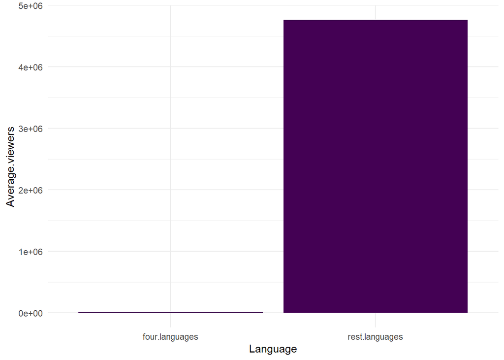

```r
# adding the sum of the four countries views and comparing it with the total one.
four.languages=
  sum(data$Average.viewers[which(data$Language=="Czech")]) +
  sum(data$Average.viewers[which(data$Language=="Hungarian")]) +
  sum(data$Average.viewers[which(data$Language=="Finnish")]) +
  sum(data$Average.viewers[which(data$Language=="Swedish")])

# obtaining the total viewers - the four countries
rest.languages = sum(data$Average.viewers) - four.languages

# for creating a small data frame and plotting it.
Language = c("four.languages", "rest.languages")
Average.viewers = c(four.languages,rest.languages)

# to plot:
comparing = data.frame(Language, Average.viewers)

ggplot(comparing) +
  aes(x = Language, y = Average.viewers) +
  geom_col(fill = "#440154") +
  theme_minimal()
```

As observed, countries with ratio lower than 1 are minimal, so they have a minimal impact on the industry.

### B. Most positive correlated: peak/average viewers and followers(gained).

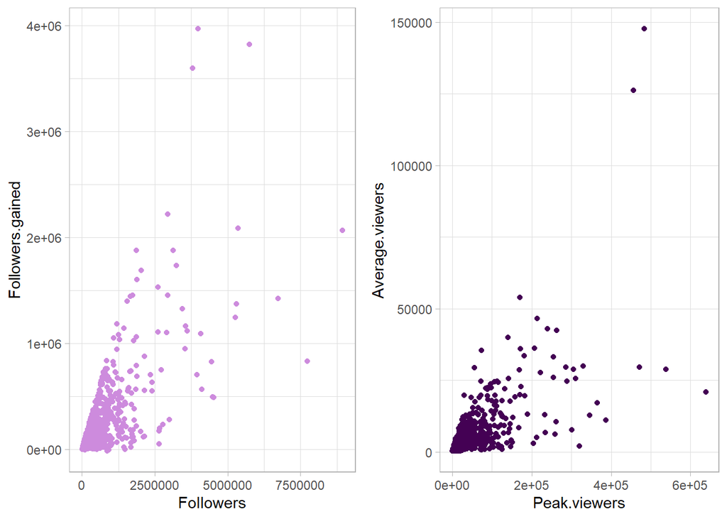

```r
ggplot1= ggplot(data) +
  aes(x = Followers, y = Followers.gained) +
  geom_point(shape = "circle", size = 1.5, colour = "#CD8BDD") +         theme_light()

ggplot2 = ggplot(data) +
  aes(x = Peak.viewers, y = Average.viewers) +
  geom_point(shape = "circle", size = 1.5, colour = "#440154") +
  theme_light()

grid.arrange(ggplot1, ggplot2, ncol = 2)
```

Obviously, the correlation of these variables is the highest as:

- A highest number of followers gained in 2020 will lead to a highest number of followers in total and will contribute to getting a bigger channel.
- A highest peak of viewers may provide the streamer more usual viewers.

### C. Most popular languages

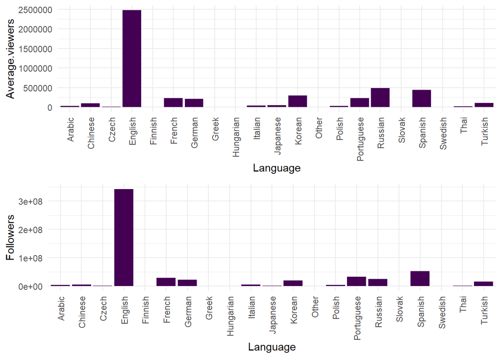

```r
ggplot1 = ggplot(data) + aes(x = Language, y = Average.viewers) +               geom_col(fill = "#440154") + theme_minimal() +
            theme(axis.text.x = element_text(angle = 90, vjust =              0.5, hjust=1))

ggplot2 = ggplot(data) + aes(x = Language, y = Followers) +               geom_col(fill = "#440154") + theme_minimal()+                       theme(axis.text.x =   element_text(angle = 90, vjust =              0.5, hjust=1))

grid.arrange(ggplot1, ggplot2, ncol = 1)
```

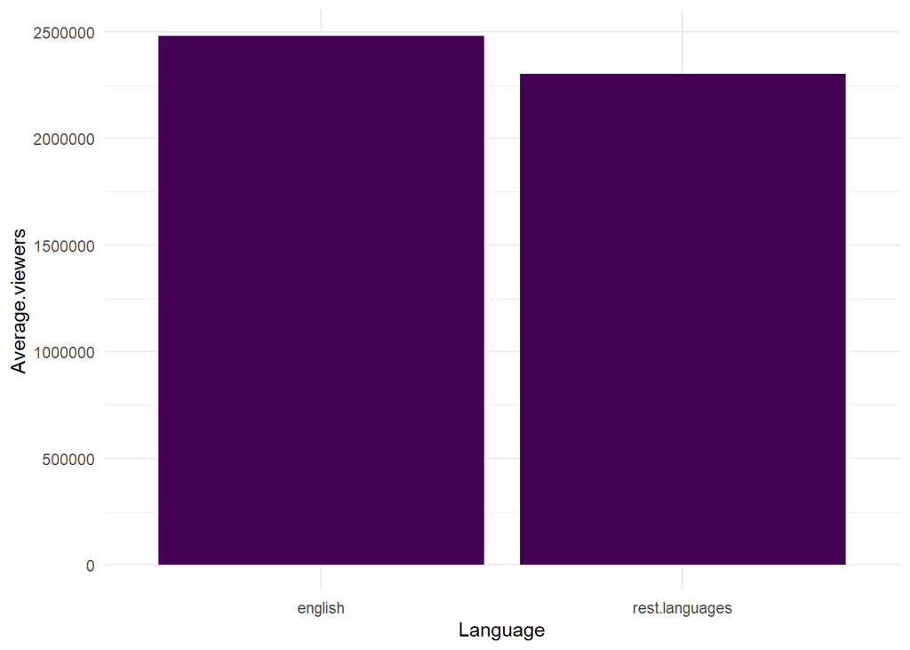

```r
english = sum(data$Average.viewers[which(data$Language == "English")])

rest.languages = sum(data$Average.viewers) - english

# for creating a small data frame and plotting it.
Language = c("english", "rest.languages")
Average.viewers = c(english,rest.languages)

# to plot:
comparing = data.frame(Language, Average.viewers)

ggplot(comparing) +
  aes(x = Language, y = Average.viewers) +
  geom_col(fill = "#440154") +
  theme_minimal()
```

Even when adding all the views other languages channels hold, English continue having more.

### D. Watch time min, Stream.time.min and Partenered

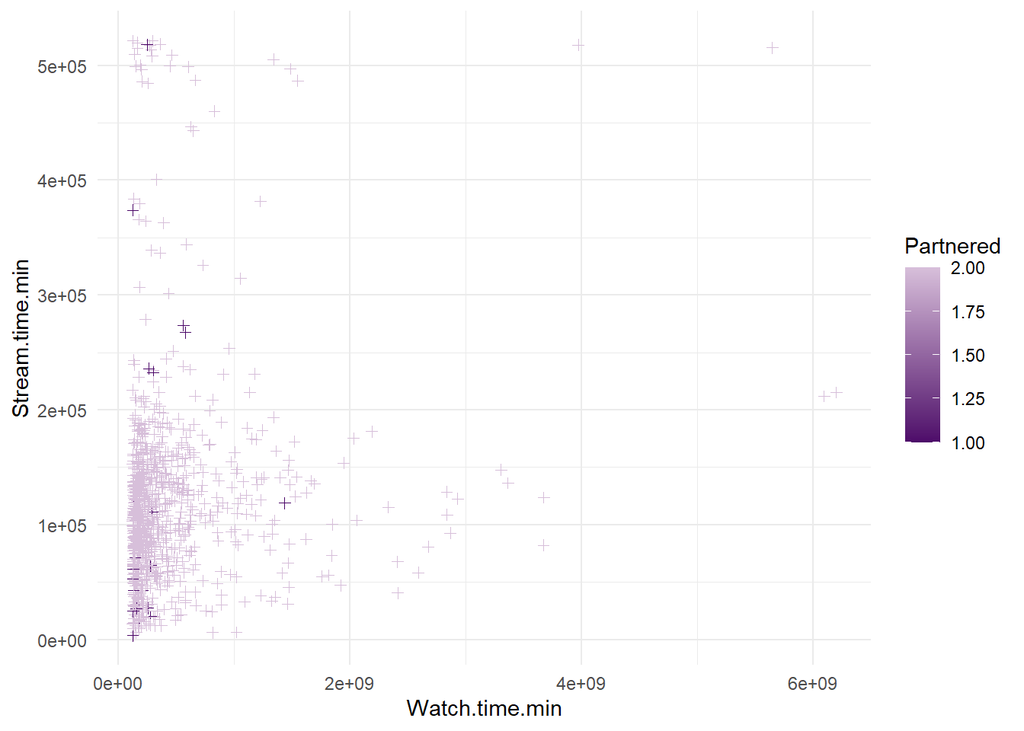

```r
ggplot(data) +
  aes(
    x = Watch.time.min,
    y = Stream.time.min,
    colour = Partnered
  ) +
  geom_point(shape = "plus", size = 1.5) +
  scale_color_gradient(low = "#4D0969", high = "#D7BFDA") +
  theme_minimal()
```

It is observed that non-Partnered streamers have a mean Watch.time.min significantly smaller than the streamers that are partnered.

Testing it:

```r
# mean of the Watch.time of NON PARTNERED
mean1=mean(data$Watch.time.min[which(data$Partnered==1)]);mean1
```

```
## [1] 278295633
```

```r
# mean of the Watch.time of PARTNERED
mean2=mean(data$Watch.time.min[which(data$Partnered==2)]);mean2
```

```
## [1] 421580190
```

```r
mean2>mean1
```

```
## [1] TRUE
```

What is more, what happens to the Stream.time.min variable when focusing on the partnered? From the previous plot we can’t assume nothing. Let’s check it in more detailed:

```r
# mean of the Stream.time of NON PARTNERED
mean1=mean(data$Stream.time.min[which(data$Partnered==1)]);mean1
```

```
## [1] 124539.5
```

```r
# mean of the Stream.time of PARTNERED
mean2=mean(data$Stream.time.min[which(data$Partnered==2)]);mean2
```

```
## [1] 120424.6
```

```r
mean2>mean1
```

```
## [1] FALSE
```

So, although non-partnered streamers stream more minutes, they have less watch time minutes.

### E. Partnered, views and followers

Before, it has been analysed Partnered wit Watch.Time.Min and Stream.Time.Min. But how does being Partnered affect the channel?

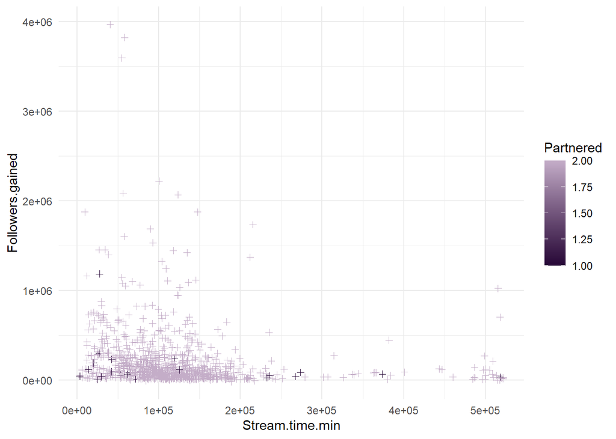

```r
ggplot(data) +
  aes(x = Stream.time.min,
    y = Followers.gained,
    colour = Partnered
  ) +
  geom_point(shape = "plus", size = 1.5) +
  scale_color_gradient(low = "#260636", high = "#C4ADC8") +
  theme_minimal()
```

As observed, only few people among the top 1000 streamers is not partnered.  
Furthermore, non-partnered people are distributed among all the x axis (as said before, the Stream.Time.Min of Non-partnered people have all different values).  
Despite this, their followers are all grouped in the smallest values.

Does partnered people have more views and followers?

*It is going to be used the mean of Followers and Viewers because there are only few streamers non-partnered and the sum would provide us very different numbers.*

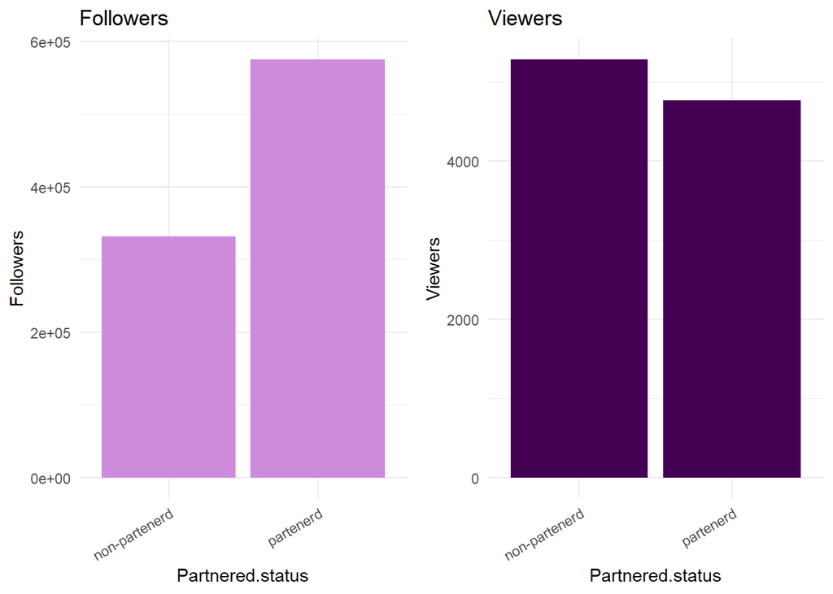

```r
# followeres of different categories
foll1 = mean(data$Followers[which(data$Partnered==1)])
foll2 = mean(data$Followers[which(data$Partnered==2)])

Partnered.status = c("non-partenerd", "partenerd")
Followers = c(foll1, foll2)

comparing1 = data.frame(Partnered.status, Followers)

# average viewers of different categories
views1 = mean(data$Average.viewers[which(data$Partnered==1)])
views2 = mean(data$Average.viewers[which(data$Partnered==2)])

Viewers = c(views1, views2)

comparing2 = data.frame(Partnered.status, Followers)

ggplot1 = ggplot(comparing1) +
  aes(x = Partnered.status, y = Followers) +
  geom_col(fill = "#CD8BDD") +
  theme_minimal() + theme(axis.text.x =element_text(angle = 30,       vjust = 1, hjust=1)) +
  labs(title="Followers")

ggplot2 = ggplot(comparing2) +
  aes(x = Partnered.status, y = Viewers) +
  geom_col(fill = "#440154") +
  theme_minimal() + theme(axis.text.x =element_text(angle = 30,       vjust = 1, hjust=1)) +
  labs(title="Viewers")


grid.arrange(ggplot1, ggplot2, ncol = 2)
```

As seen, on mean, non-partnered people have more viewers. So a conclusion would be that once you are on top 1000 streamers, your status does not define your success.

## Conclusions

- **Non-partnered streamers** on mean have: more Stream.time.min, less Watch.time.min, more Average.viewers and less Followers
- **Mature content** has less viewers.
- There is a big difference of **viewers among languages**. ore than half of viewers consume **English** content.
- A **peak in viewers** can lead to an increment of viewers in the future. The same happens with **followers**.

## 3. Principal Component Analysis

For PCA, our data set with only numeric variables (data.num) which is already scaled is going to be used.

```r
pca = prcomp(data.num)
# From dimension 1 to dimension 9 to check importance of the components
summary(pca)
```

```
## Importance of components:
##                           PC1    PC2    PC3    PC4     PC5     PC6     PC7
## Standard deviation     1.8509 1.1093 1.0093 0.9919 0.89361 0.83639 0.56384
## Proportion of Variance 0.3807 0.1367 0.1132 0.1093 0.08873 0.07773 0.03532
## Cumulative Proportion  0.3807 0.5174 0.6306 0.7399 0.82861 0.90633 0.94166
##                            PC8     PC9
## Standard deviation     0.53422 0.48960
## Proportion of Variance 0.03171 0.02663
## Cumulative Proportion  0.97337 1.00000
```

```r
# Mathematical format
eigen(R)
```

```
## eigen() decomposition
## $values
## [1] 3.4259155 1.2305468 1.0186795 0.9837705 0.7985331 0.6995515 0.3179111
## [8] 0.2853884 0.2397035
##
## $vectors
##              [,1]        [,2]        [,3]         [,4]        [,5]         [,6]
##  [1,] -0.44201004  0.34070397  0.04780466  0.026004481  0.03606338 -0.004847499
##  [2,]  0.07242139  0.77932462  0.07105305 -0.068967497 -0.18879502 -0.485851940
##  [3,] -0.43607411 -0.09873545  0.00288804  0.080771529  0.24414343 -0.409051134
##  [4,] -0.39790533 -0.26042268 -0.07211104  0.119711483  0.37833428 -0.380668639
##  [5,] -0.43922016 -0.01690068  0.10879856  0.002644615 -0.46431279  0.107625332
##  [6,] -0.41334999 -0.11495534  0.08182067  0.004869992 -0.51999497  0.204586268
##  [7,] -0.28355515  0.41337853 -0.19426761 -0.082835755  0.46895131  0.614986307
##  [8,] -0.01932414 -0.04906721  0.87722466 -0.414137643  0.22447385  0.053316218
##  [9,]  0.07964597  0.11052382  0.40207347  0.891801498  0.06346702  0.131161816
##              [,7]         [,8]        [,9]
##  [1,]  0.34056393  0.483707894  0.57819135
##  [2,] -0.26437766 -0.092951970 -0.16544471
##  [3,]  0.34577623 -0.666280665  0.05602080
##  [4,] -0.50256173  0.406182370 -0.22073216
##  [5,]  0.33768403  0.175106231 -0.65045647
##  [6,] -0.54871327 -0.283840854  0.33956814
##  [7,] -0.15307164 -0.189853866 -0.21567127
##  [8,] -0.05049099 -0.004809975 -0.01955211
##  [9,] -0.02990235 -0.034309081 -0.03413610
```

With how many components most of the variability will be explained?

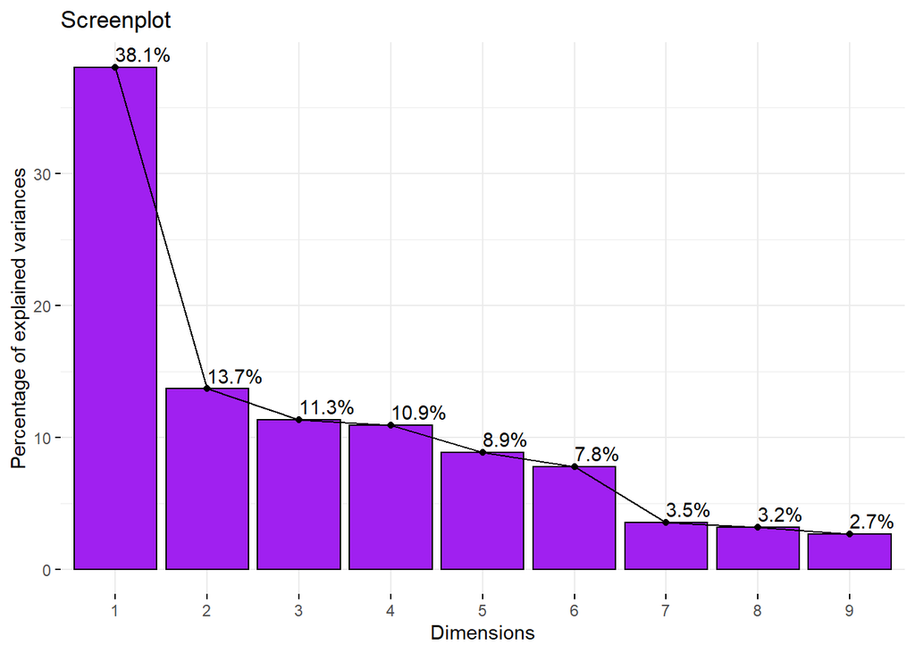

```r
# How many components?
fviz_screeplot(pca, addlabels = TRUE, title = "Screenplot", barfill = "purple", barcolor = "black")
```

With the first 4 dimensions, we would explain 74% of the variability. With the first 5 dimensions, 83%.

Now, interpretation of components.

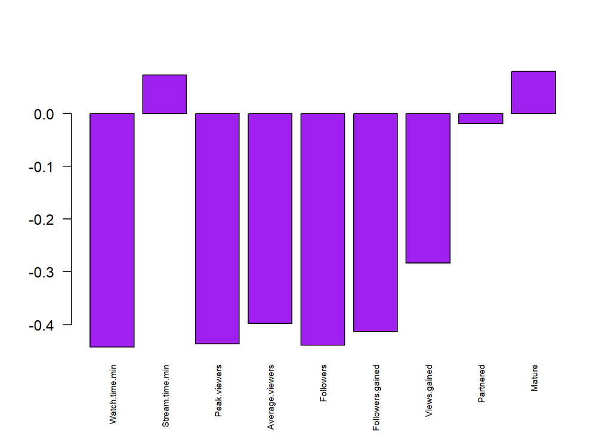

```r
# first component
barplot(pca$rotation[,1], las=2, col="purple", cex.names = 0.6)
```

```r
# should be 1 (eigenvectors)
sum(pca$rotation[,1]^2)
```

```
## [1] 1
```

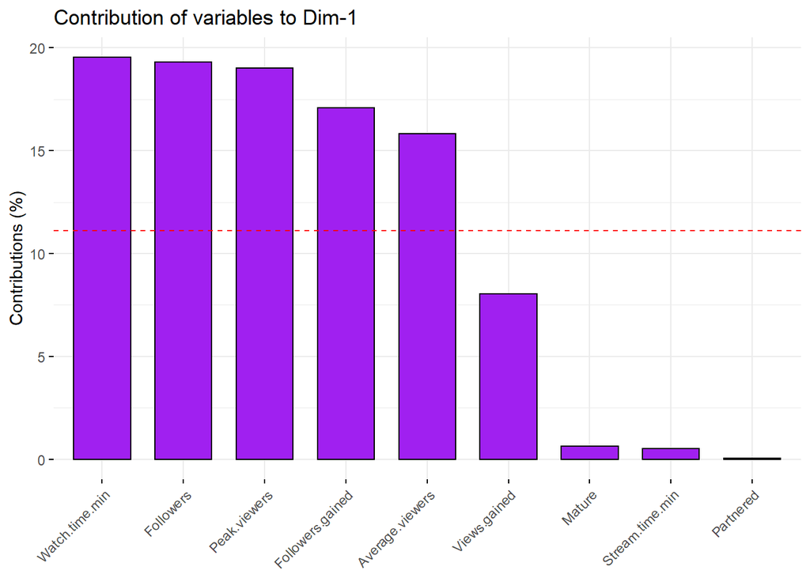

```r
# plotting squared loadings (contribution of variables to components)
fviz_contrib(pca, choice = "var", axes = 1, fill = "purple", color = "black")
```

As seen, only the first five variables come to the expected value of contribution.

With this information, top channels can be ranked.

```r
# Ranking top channels

# WORST
names[order(pca$x[,1])][(length(names)-10):length(names)]
```

```
##  [1] "DownToQuest"     "runitup247"      "livekiss"        "Sonecarox"
##  [5] "RelaxBeats"      "SaltyTeemo"      "murilo_RT"       "Japan_ASMR"
##  [9] "voicetv"         "SlotRoom247"     "MarketTradersTV"
```

```r
# BEST
names[order(pca$x[,1])][1:10]
```

```
##  [1] "Tfue"                   "Rubius"                 "summit1g"
##  [4] "TheGrefg"               "auronplay"              "xQcOW"
##  [7] "Fextralife"             "dota2ti"                "Riot Games (riotgames)"
## [10] "shroud"
```

Using the second component:

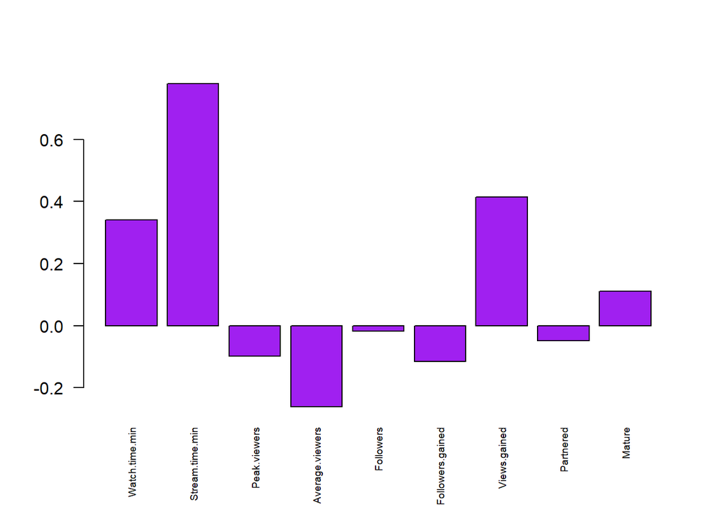

```r
barplot(pca$rotation[,2], las=2, col="purple", cex.names = 0.6)
```

```r
# WORST
names[order(pca$x[,2])][(length(names)-10):length(names)]
```

```
##  [1] "mch_AGG"         "SaltyTeemo"      "summit1g"        "xQcOW"
##  [5] "allkeyshop_tv"   "BeyondTheSummit" "Solary"          "OgamingLoL"
##  [9] "ESL_CSGO"        "Gaules"          "Fextralife"
```

```r
# TOP
names[order(pca$x[,2])][1:10]
```

```
##  [1] "dota2ti"           "dota2ti_ru"        "SLAKUN10"
##  [4] "Fortnite"          "auronplay"         "shroud"
##  [7] "Warframe"          "TheGrefg"          "KEEMSTAR"
## [10] "DreamHackDota2_RU"
```

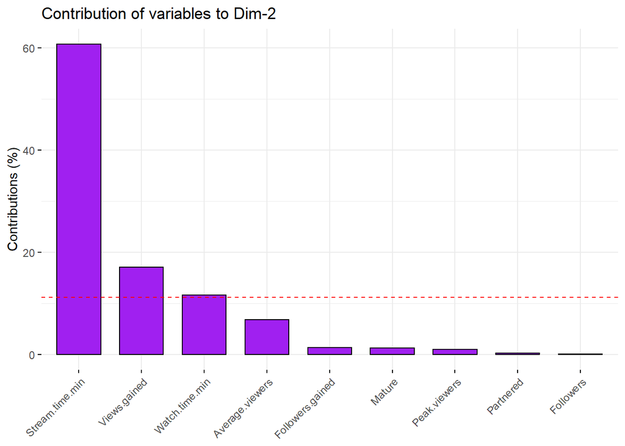

```r
# contribution
fviz_contrib(pca, choice = "var", axes = 2, color = "black", fill = "purple", cex.axis = 0.6)
```

Less variables came to the expected value of contribution.

```r
# checking contribution of each streamer

# between 0 and 100%
head(get_pca_ind(pca)$contrib[,1])
```

```
##        1        2        3        4        5        6
## 3.715038 4.477396 2.488572 1.933178 5.106291 1.703337
```

```r
# between 0 and 1
head((pca$x[,1]^2)/(pca$sdev[1]^2))/dim(data.num)[1]
```

```
## [1] 0.03715038 0.04477396 0.02488572 0.01933178 0.05106291 0.01703337
```

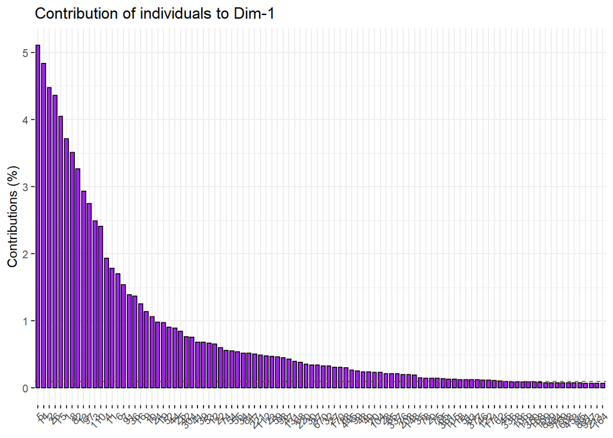

```r
# visualization of top 100 streamers contribution
fviz_contrib(pca, choice = "ind", axes = 1, top=100, color = "black", fill = "purple")
```

```r
# which are the top 15?
names[order(get_pca_ind(pca)$contrib[,1],decreasing=T)][1:15]
```

```
##  [1] "Tfue"                   "Rubius"                 "summit1g"
##  [4] "TheGrefg"               "auronplay"              "xQcOW"
##  [7] "Fextralife"             "dota2ti"                "Riot Games (riotgames)"
## [10] "shroud"                 "Gaules"                 "dota2ti_ru"
## [13] "ESL_CSGO"               "TimTheTatman"           "Asmongold"
```

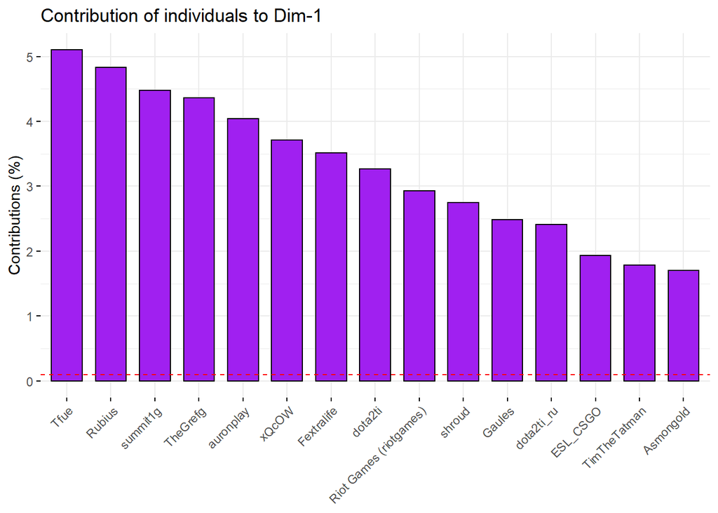

```r
# zooming the contribution plot

# TOP 15
names_z1 = names[order(get_pca_ind(pca)$contrib[,1],decreasing=T)]
fviz_contrib(pca, choice = "ind", axes = 1, top=15, color = "black", fill = "purple")+scale_x_discrete(labels=names_z1)
```

Now, biplot of our PCA is going to be created.

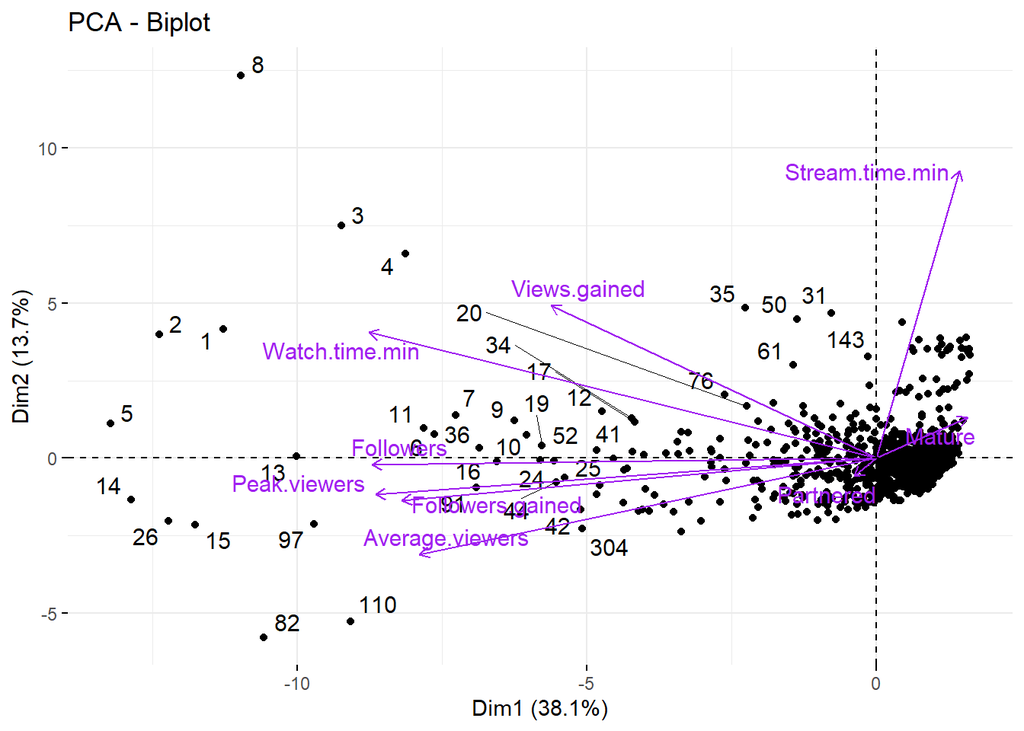

```r
# good plot although a lot of information
fviz_pca_biplot(pca, repel = TRUE, col.var = "purple")
```

The first two scores are going to be studied:

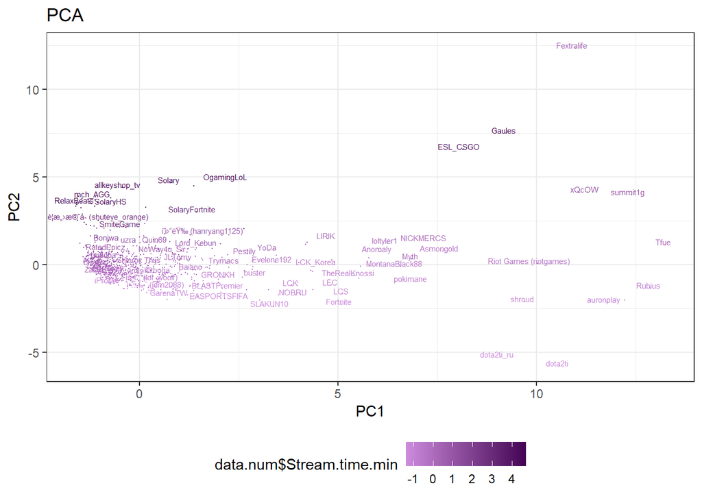

```r
# using minutes streamed for color
data.frame(z1=-pca$x[,1],z2=pca$x[,2]) %>%
  ggplot(aes(z1,z2,label=names,color=data.num$Stream.time.min)) +
  geom_point(size=0) +
  labs(title="PCA", x="PC1", y="PC2") +
  theme_bw() + scale_color_gradient(low="#CD8BDD", high="#440154")+theme(legend.position="bottom") +   geom_text(size=2, hjust=0.6, vjust=0, check_overlap = TRUE)
```

The two PCAs seem independent by the result of the plot.

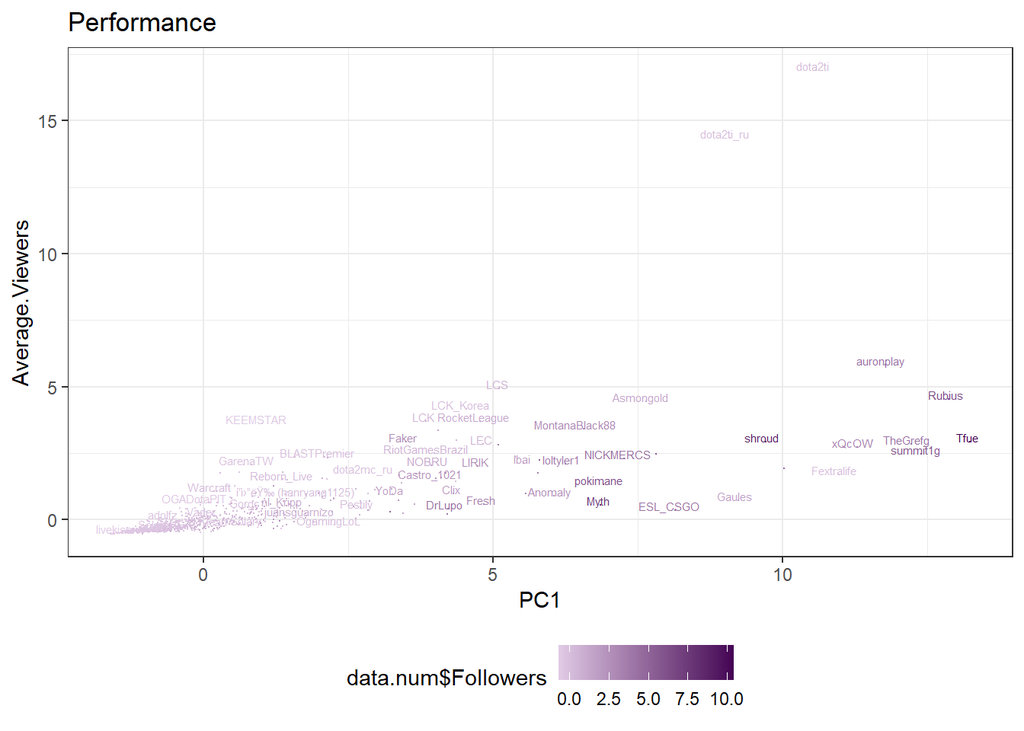

```r
data.frame(z1=-pca$x[,1],z2=data.num$Average.viewers) %>%
  ggplot(aes(z1,z2,label=names,color=data.num$Followers)) + geom_point(size=0) +
  labs(title="Performance", x="PC1", y="Average.Viewers") +
  scale_color_gradient(low="#E1CBE6", high="#440154") +
  theme_bw() + theme(legend.position="bottom") + geom_text(size=2, hjust=0.6, vjust=0, check_overlap = TRUE)
```

Better streamers have more Average.viewers and more Follorers. A positive linear relation can be seen, although it is a bit lost when PC1 is higher.

The same is going to be done but changing the color to Mature and the Y axis to Watch.Time.Min.

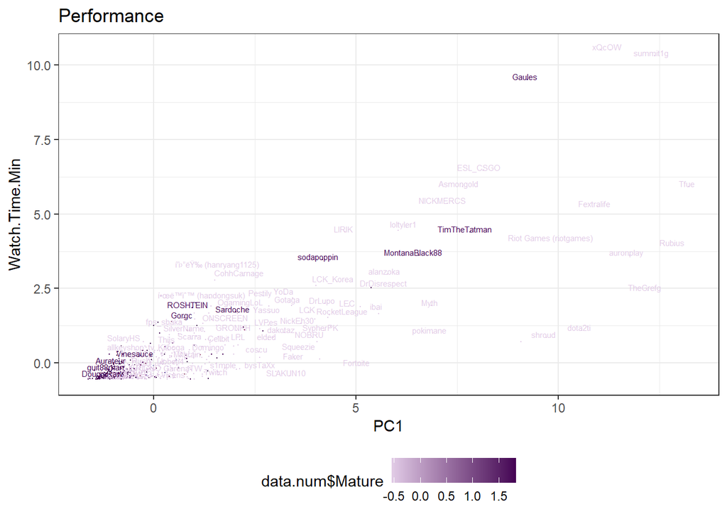

```r
data.frame(z1=-pca$x[,1],z2=data.num$Watch.time.min) %>%
  ggplot(aes(z1,z2,label=names,color=data.num$Mature)) + geom_point(size=0) +
  labs(title="Performance", x="PC1", y="Watch.Time.Min") +
  scale_color_gradient(low="#E1CBE6", high="#440154") +
  theme_bw() + theme(legend.position="bottom") + geom_text(size=2, hjust=0.6, vjust=0, check_overlap = TRUE)
```

Again, a positive linear relationship is shown. Furthermore, almost all values of mature content are grouped in low values of the PC1 and Watch.Time.Min.

-PC2-

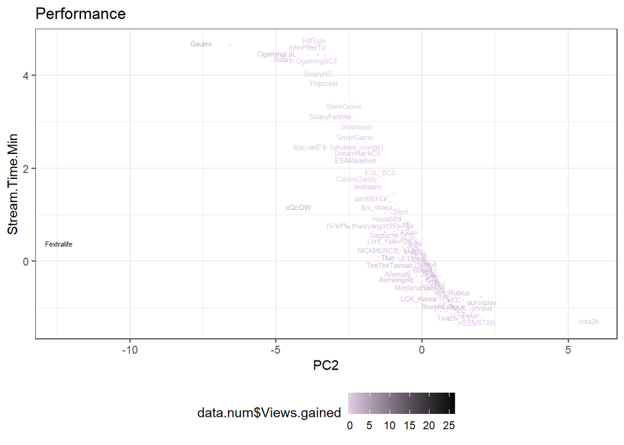

```r
data.frame(z1=-pca$x[,2],z2=data.num$Stream.time.min) %>%
  ggplot(aes(z1,z2,label=names,color=data.num$Views.gained)) + geom_point(size=0) +
  labs(title="Performance", x="PC2", y="Stream.Time.Min") +
  scale_color_gradient(low="#E1CBE6", high="black") +
  theme_bw() + theme(legend.position="bottom") + geom_text(size=2, hjust=0.6, vjust=0, check_overlap = TRUE)
```

*Note that the data is scale, that’s why there would be negative valies*

Summarizing, it can be remembered the contribution of the variables in each PCA. It is used fviz_pca_var instead of biplot in order not to show individuals (which is a little bit messy).

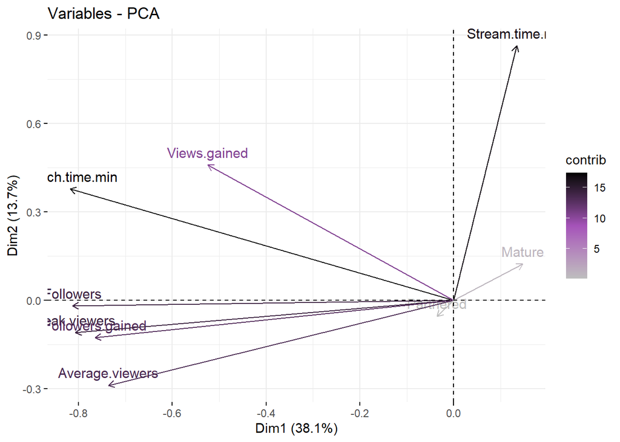

```r
fviz_pca_var(pca, col.var = "contrib",
             gradient.cols = c("grey", "#A553B9", "black"), ggtheme = theme_minimal())
```

## 4. Factor analysis

```r
x.f <- factanal(data.num, factors = 3, rotation="none", scores="regression")
x.f
```

```
##
## Call:
## factanal(x = data.num, factors = 3, scores = "regression", rotation = "none")
##
## Uniquenesses:
##   Watch.time.min  Stream.time.min     Peak.viewers  Average.viewers
##            0.005            0.786            0.421            0.014
##        Followers Followers.gained     Views.gained        Partnered
##            0.224            0.331            0.714            0.996
##           Mature
##            0.986
##
## Loadings:
##                  Factor1 Factor2 Factor3
## Watch.time.min    0.980  -0.185
## Stream.time.min          -0.393  -0.232
## Peak.viewers      0.662   0.349   0.137
## Average.viewers   0.631   0.767
## Followers         0.647           0.597
## Followers.gained  0.552   0.107   0.594
## Views.gained      0.520  -0.102
## Partnered
## Mature
##
##                Factor1 Factor2 Factor3
## SS loadings      2.800   0.928   0.797
## Proportion Var   0.311   0.103   0.089
## Cumulative Var   0.311   0.414   0.503
##
## Test of the hypothesis that 3 factors are sufficient.
## The chi square statistic is 20.64 on 12 degrees of freedom.
## The p-value is 0.0559
```

It is noted that the Mature and Partnered variable have an uniqueness (=noise) of almost 1, which means that the factors do not account well for its variance.

In loadings it is measured the contribution of that variable to the factor.

A factor is worth keeping if the SS loading is greater than 1 (Kaiser’s rule). This happens to us with Factor 1.

Focusing on loadings and uniqueness:

```r
cbind(x.f$loadings, x.f$uniquenesses)
```

```
##                      Factor1     Factor2     Factor3
## Watch.time.min    0.98010471 -0.18515399 -0.01066825 0.00500000
## Stream.time.min   0.07675188 -0.39311672 -0.23220506 0.78565151
## Peak.viewers      0.66200270  0.34864173  0.13746682 0.42130551
## Average.viewers   0.63057107  0.76713925 -0.01660842 0.01360166
## Followers         0.64682179  0.03962128  0.59687541 0.22379135
## Followers.gained  0.55169266  0.10689692  0.59408140 0.33127595
## Views.gained      0.52028874 -0.10249696 -0.07256366 0.71352733
## Partnered         0.03225046 -0.03700332  0.03956753 0.99602833
## Mature           -0.05698411 -0.06177824 -0.08605733 0.98553278
```

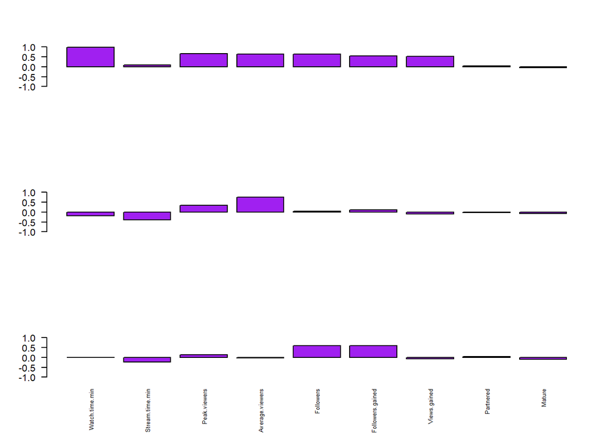

```r
# plotting loadings of the 3 factors
par(mfrow=c(3,1))
barplot(x.f$loadings[,1], names=F, las=2, col="purple", ylim = c(-1, 1), cex.names = 0.7)
barplot(x.f$loadings[,2], names=F, las=2, col="purple", ylim = c(-1, 1), cex.names = 0.7)
barplot(x.f$loadings[,3], las=2, col="purple", ylim = c(-1, 1), cex.names = 0.6)
```

The same process will be repeated but with 2 factors, a different rotation and different scores.

```r
x.f <- factanal(data.num, factors = 2, rotation="varimax", scores="Bartlett", lower = 0.01)
x.f
```

```
##
## Call:
## factanal(x = data.num, factors = 2, scores = "Bartlett", rotation = "varimax",     lower = 0.01)
##
## Uniquenesses:
##   Watch.time.min  Stream.time.min     Peak.viewers  Average.viewers
##            0.010            0.748            0.358            0.408
##        Followers Followers.gained     Views.gained        Partnered
##            0.475            0.557            0.716            0.999
##           Mature
##            0.984
##
## Loadings:
##                  Factor1 Factor2
## Watch.time.min    0.983   0.157
## Stream.time.min   0.225  -0.449
## Peak.viewers      0.492   0.632
## Average.viewers   0.377   0.670
## Followers         0.558   0.463
## Followers.gained  0.446   0.495
## Views.gained      0.530
## Partnered
## Mature                   -0.122
##
##                Factor1 Factor2
## SS loadings      2.193   1.551
## Proportion Var   0.244   0.172
## Cumulative Var   0.244   0.416
##
## Test of the hypothesis that 2 factors are sufficient.
## The chi square statistic is 383.89 on 19 degrees of freedom.
## The p-value is 9.76e-70
```

The most noticeable thing is our p-value, which is almost 0, meaning that this model should be rejected.

Furthermore, uniqueness continue to be very high in several variables.

Despite this, SS loadings are good (higher than 1).

```r
cbind(x.f$loadings, x.f$uniquenesses)
```

```
##                      Factor1     Factor2
## Watch.time.min    0.98259424  0.15655846 0.0100000
## Stream.time.min   0.22454731 -0.44868051 0.7482632
## Peak.viewers      0.49238114  0.63195617 0.3581920
## Average.viewers   0.37703620  0.67037255 0.4084443
## Followers         0.55775352  0.46264153 0.4748743
## Followers.gained  0.44596583  0.49456981 0.5565141
## Views.gained      0.52971274  0.05578139 0.7162958
## Partnered         0.03760942  0.00623061 0.9985544
## Mature           -0.02525276 -0.12205795 0.9844601
```

The loadings are plotted:

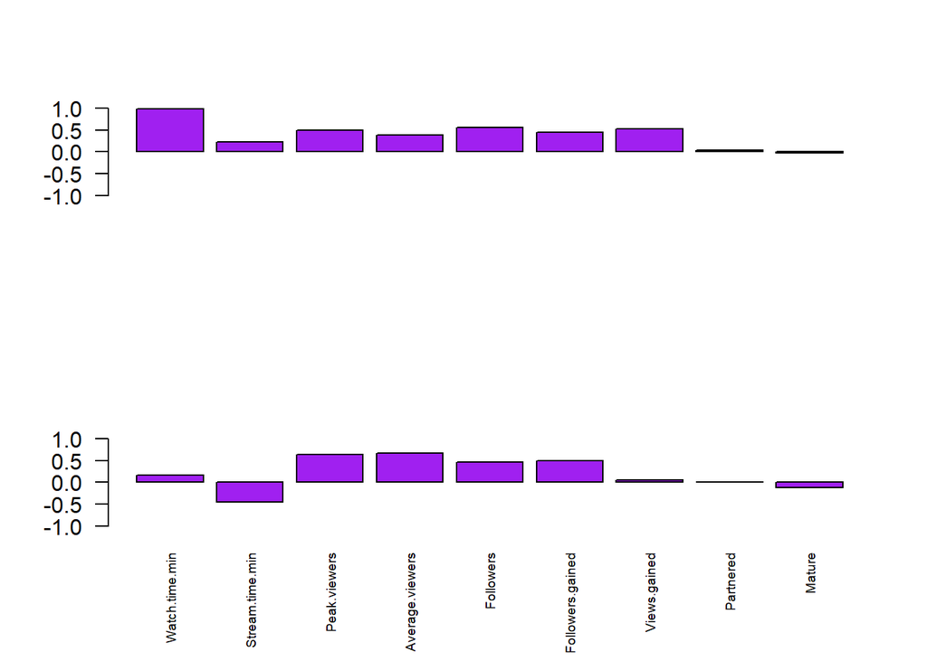

```r
par(mfrow=c(2,1))
barplot(x.f$loadings[,1], names=F, las=2, col="purple", ylim = c(-1, 1), cex.names = 0.6)
barplot(x.f$loadings[,2], las=2, col="purple", ylim = c(-1, 1),cex.names = 0.6)
```

## Conclusions:

- In the first model, **Watch.Time.Min and Average.Viewers** could explain 99% if the variability.
- On the other side, **Partnered, Mature and Stream.Time.Min** produce a lot of noise and does not contribute to it.
- **Followers** explain almost 80% of the variability which is not bad.
- The rest of the variables had a medium level of uniqueness and did not contribute much on our model.

## 5. Clustering

K-means is going to be used. The only-numeric data set is going to be used.

First, it should be defined the correct numbers of clusters. Let’s use different methods:

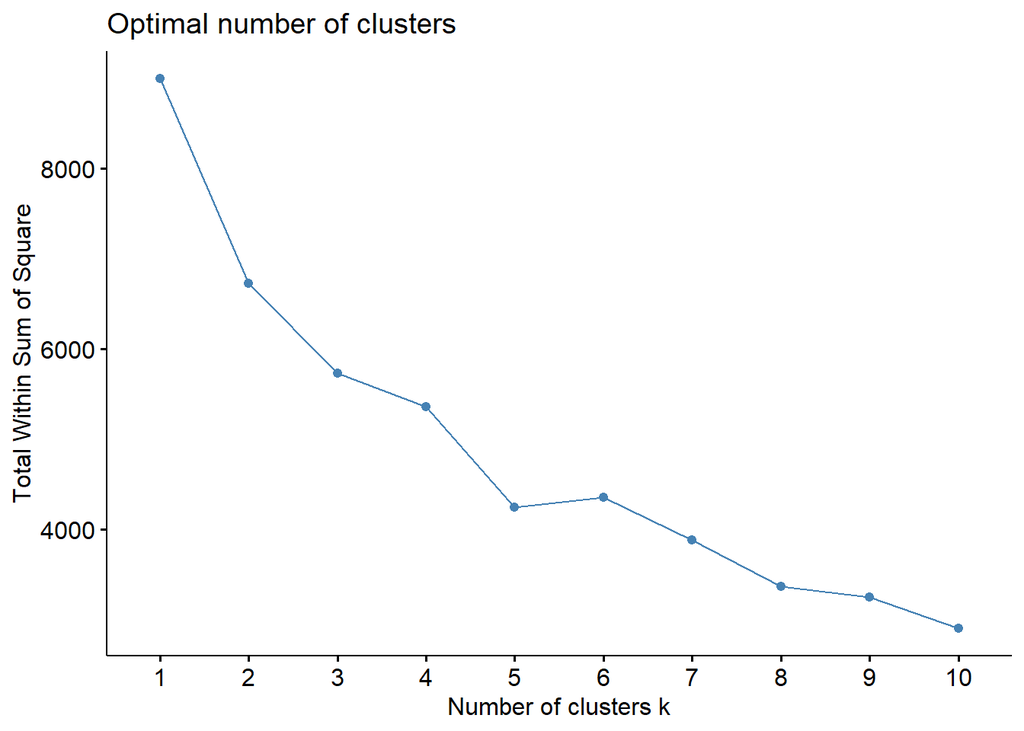

```r
#elbow method
fviz_nbclust(data.num, kmeans, method = 'wss')
```

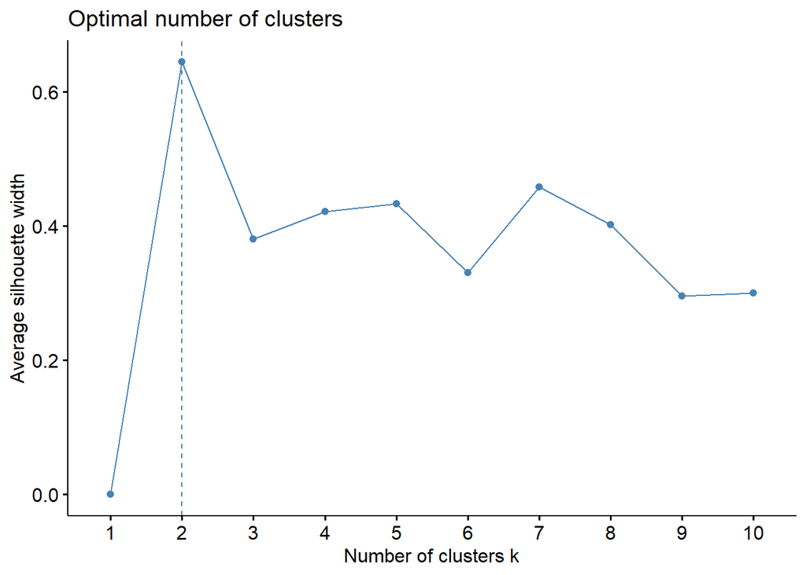

```r
#silhouette method
fviz_nbclust(data.num, kmeans, method = 'silhouette')
```

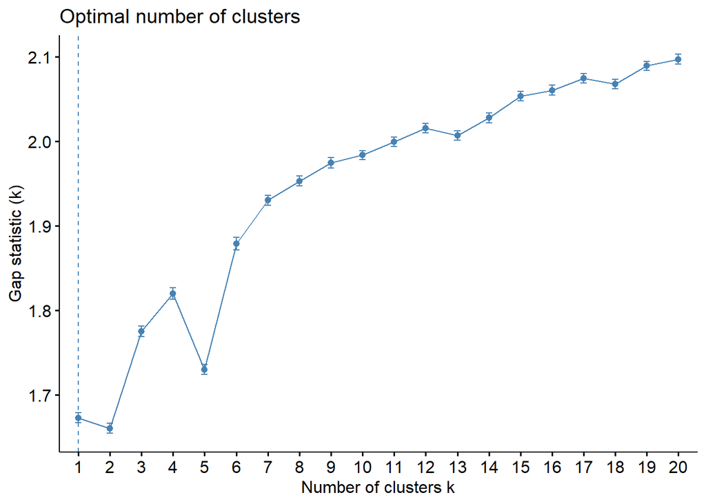

```r
#gap statitic method
fviz_nbclust(data.num, kmeans, method = 'gap_stat', k.max = 20)
```

Taking this into account, the last method (gap statistic) can be forgotten as only 1 cluster is obtained although it may be the most accurate one.

Elbow method may suggest 5 clusters although the shape is not clear.

So, let’s make 2 clusters as silhouette method suggests.

```r
fit = kmeans(data.num, centers=2, nstart=100)
groups = fit$cluster
groups
```

[output not shown]

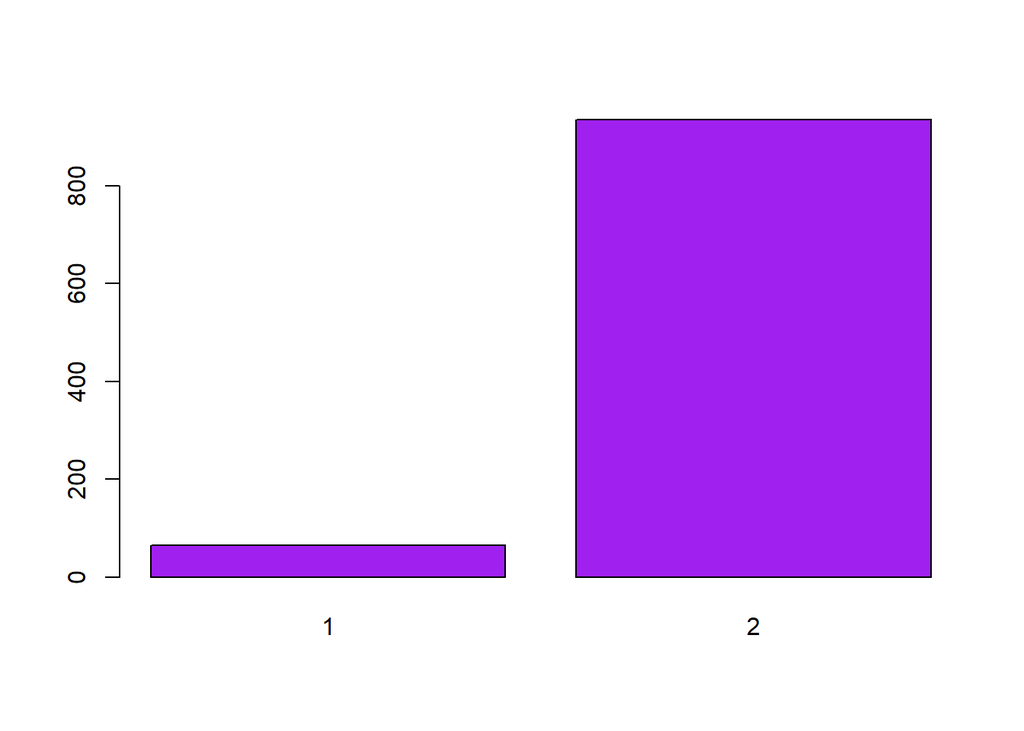

```r
barplot(table(groups), col="purple")
```

Almost all the data is in cluster 2.

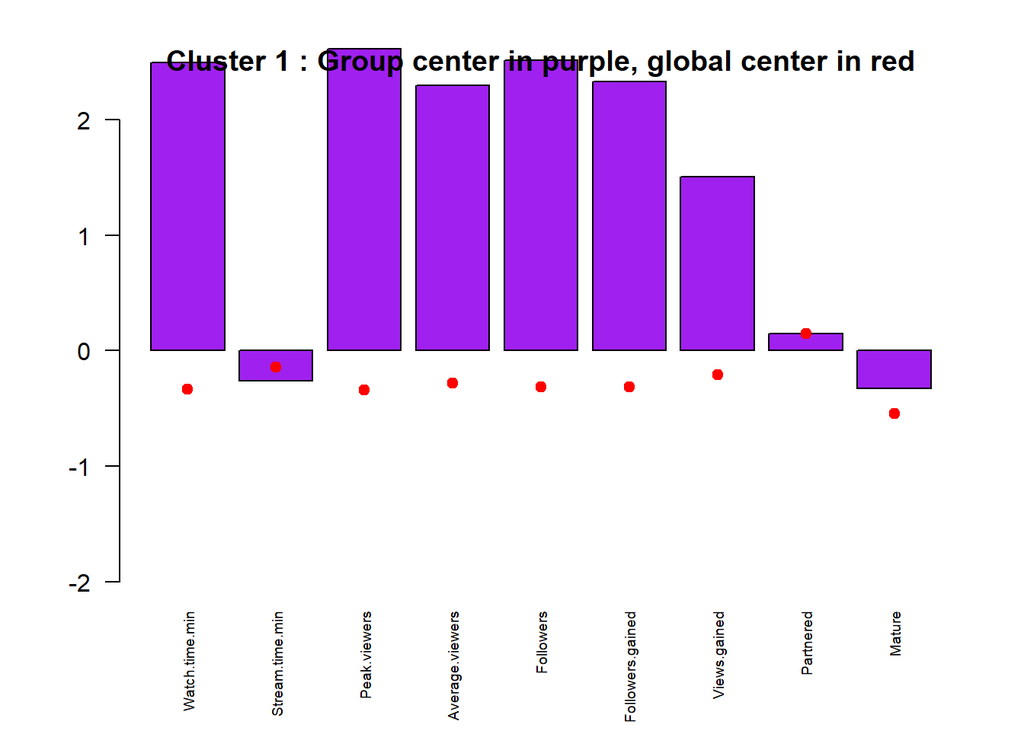

```r
centers=fit$centers

i=1  # plottinng the centers in cluster 1
bar1=barplot(centers[i,], las=2, col="purple", ylim=c(-2,2), main=paste("Cluster", i,": Group center in purple, global center in red"), cex.names = 0.6)
points(bar1,y=apply(data.num, 2, quantile, 0.50),col="red",pch=19)
```

*Note that red circles symbolizes the center of all of our data, while the bar the center of cluster 1 in this case*

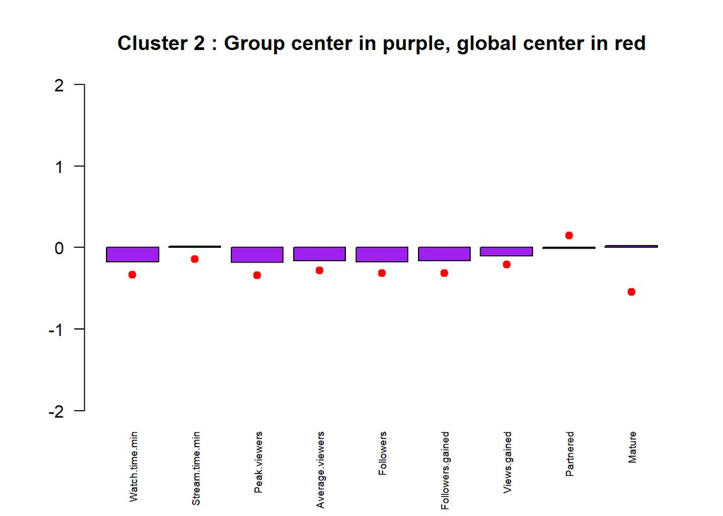

```r
i=2  # plotting the centers in cluster 2
bar2=barplot(centers[i,], las=2, col="purple", ylim=c(-2,2), main=paste("Cluster", i,": Group center in purple, global center in red"), cex.names = 0.6)
points(bar2,y=apply(data.num, 2, quantile, 0.50),col="red",pch=19)
```

*Note that red circles symbolizes the center of all of our data, while the bar the center of cluster 2 in this case*

A clusplot is created with our two previous groups.

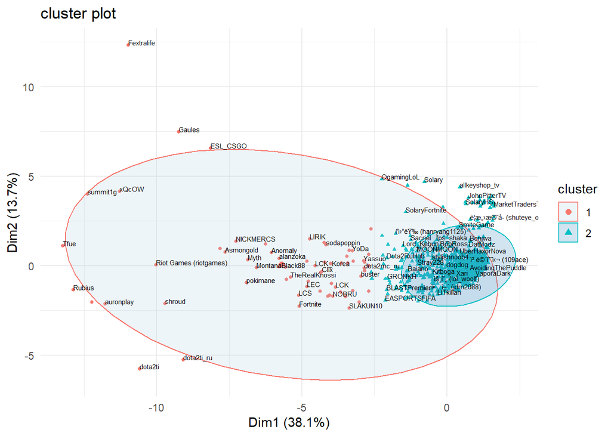

```r
# saving the plots for later
a = fviz_cluster(fit, data = data.num, geom = c("point"),ellipse.type = 'norm', pointsize=1,
main ="cluster plot")+
theme_minimal()+geom_text(label=names,hjust=0, vjust=0,size=2,check_overlap = T)+scale_fill_brewer(palette="Paired");a
```

Now, a silhouette plot is formed.

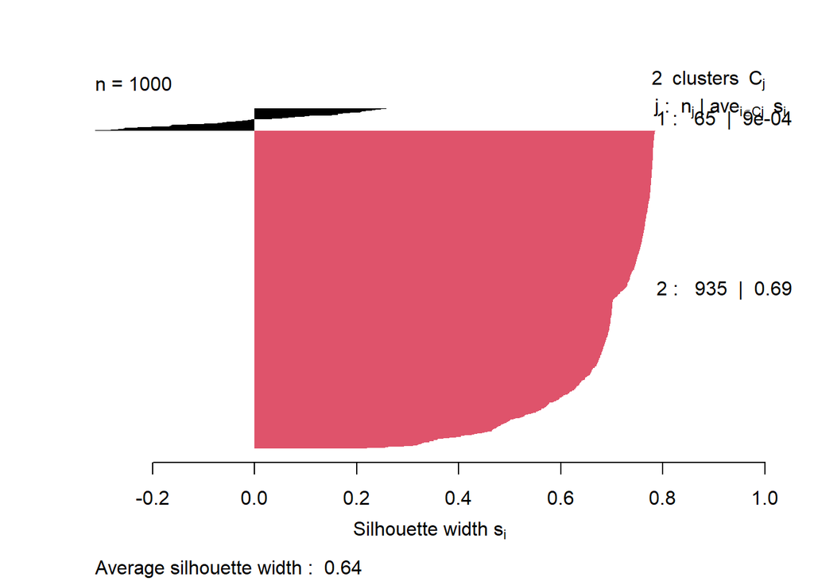

```r
dist <- dist(data.num, method="euclidean")
sil = silhouette(groups,dist)
plot(sil, col=1:2, main="", border=NA)
```

What are the difference among both clusters? Let’s study it:

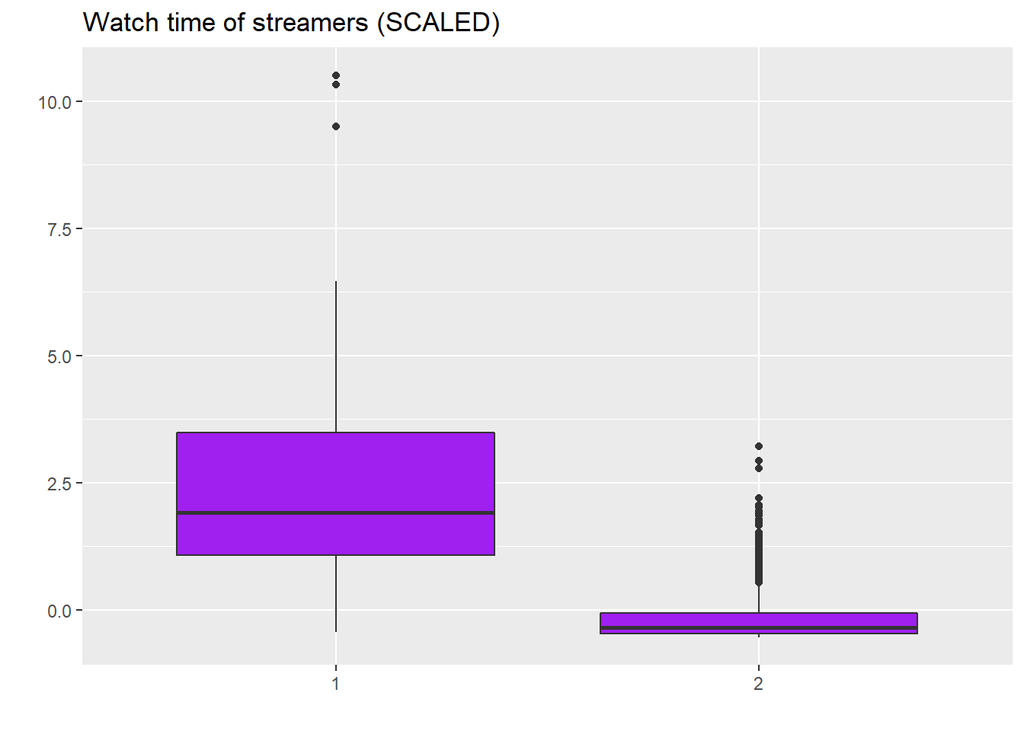

```r
as.data.frame(data.num) %>% mutate(cluster=factor(groups), Watch.time.min=Watch.time.min, Average.viewers=Average.viewers, Followers=Followers) %>%
ggplot(aes(x = cluster, y = Watch.time.min)) +
geom_boxplot(fill="purple") +
labs(title = "Watch time of streamers (SCALED)", x = "", y = "", col = "")
```

It is observed that streamers in one cluster are being watched much more than on the other cluster.

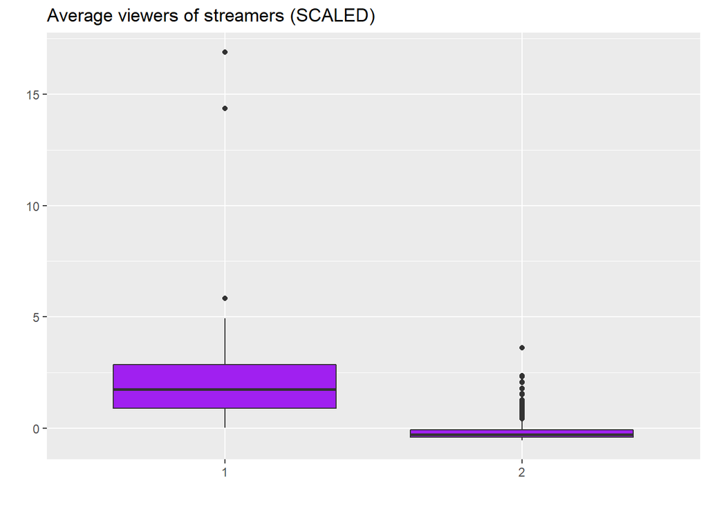

```r
as.data.frame(data.num) %>% mutate(cluster=factor(groups), Watch.time.min=Watch.time.min, Average.viewers=Average.viewers, Followers=Followers) %>%
  ggplot(aes(x = cluster, y = Average.viewers)) +
  geom_boxplot(fill="purple") +
  labs(title = "Average viewers of streamers (SCALED)", x = "", y = "", col = "")
```

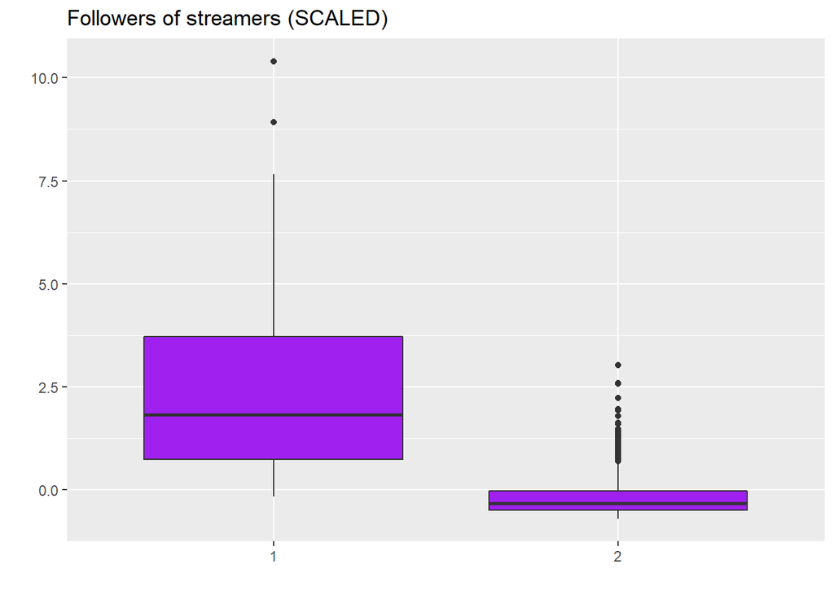

```r
as.data.frame(data.num) %>% mutate(cluster=factor(groups), Watch.time.min=Watch.time.min, Average.viewers=Average.viewers, Followers=Followers) %>%
ggplot(aes(x = cluster, y = Followers)) +
geom_boxplot(fill="purple") +
labs(title = "Followers of streamers (SCALED)", x = "", y = "", col = "")
```

The same happens for Average.viewers and Followers.

We could conclude that one cluster (2) contains the “worst” streamers in our top 1000: less followers, viewers… The other (1) contains most succesfull people on Twitch.

Now, let’s do **k means with Mahalanobis distance**.

```r
S_x <- cov(data.num)
iS <- solve(S_x)
e <- eigen(iS)
V <- e$vectors
B <- V %*% diag(sqrt(e$values)) %*% t(V)
Xtil <- scale(data.num,scale = FALSE)
dataS <- Xtil %*% B
```

```r
fit.mahalanobis = kmeans(dataS, centers=2, nstart=100)
groups = fit.mahalanobis$cluster
centers=fit.mahalanobis$centers
colnames(centers)=colnames(data.num)
centers
```

```
##   Watch.time.min Stream.time.min Peak.viewers Average.viewers    Followers
## 1    0.002916202   -0.0005933716  0.001861056    -0.001547042  0.002952721
## 2   -0.129638450    0.0263780665 -0.082732400     0.068773039 -0.131261879
##   Followers.gained Views.gained Partnered        Mature
## 1      0.001409147 -0.003287637  0.149787  9.743022e-05
## 2     -0.062643001  0.146150389 -6.658715 -4.331216e-03
```

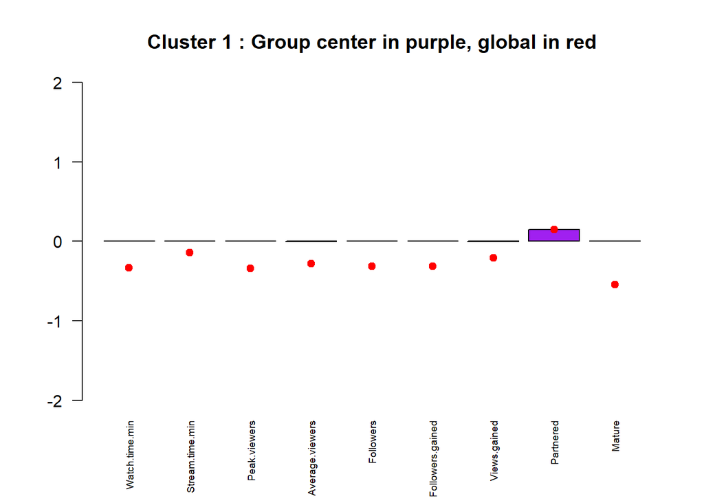

```r
i=1  # plotting the centers in cluster 1
bar1=barplot(centers[i,], las=2, col="purple", ylim=c(-2,2), main=paste("Cluster", i,": Group center in purple, global in red"), cex.names = 0.6)
points(bar1,y=apply(data.num, 2, quantile, 0.50),col="red",pch=19)
```

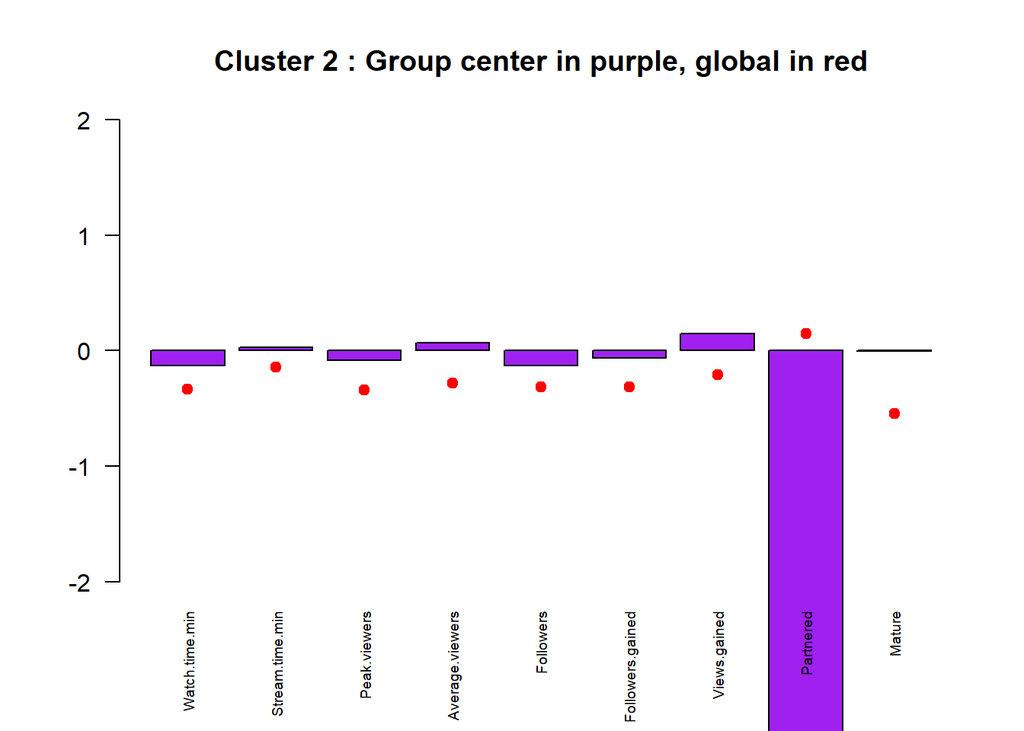

```r
i=2  # plotting the centers in cluster 2
bar2=barplot(centers[i,], las=2, col="purple", ylim=c(-2,2), main=paste("Cluster", i,": Group center in purple, global in red"), cex.names = 0.6)
points(bar2,y=apply(data.num, 2, quantile, 0.50),col="red",pch=19)
```

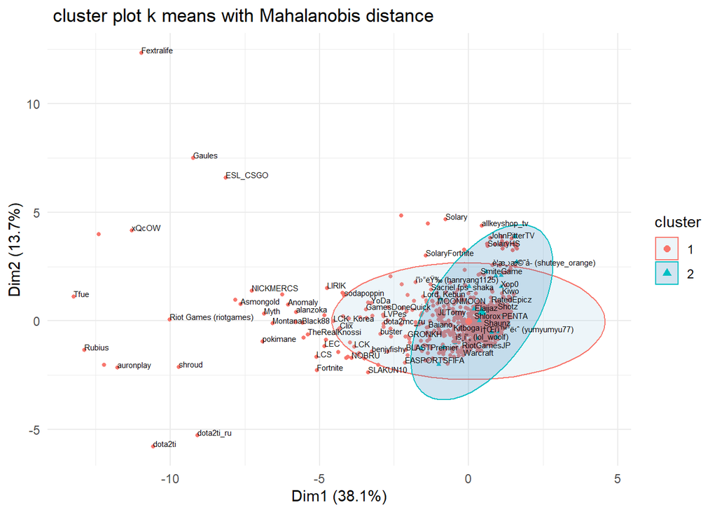

```r
b = fviz_cluster(fit.mahalanobis, data = data.num, geom = c("point"),ellipse.type = 'norm', pointsize=1,  main = " cluster plot k means with Mahalanobis distance") +
theme_minimal()+geom_text(label=names,hjust=0,vjust=0,size=2,
check_overlap = T)+scale_fill_brewer(palette="Paired");b
```

```r
adjustedRandIndex(fit$cluster, fit.mahalanobis$cluster)
```

```
## [1] -0.03083211
```

Both clustering are very very different. The first one, groups more streamers. The Mahalanobis clustering does not define our dataset completely leaving a lot of streamers outside our clusters.

It can be tried other types of clustering. Let’s see Kernel k-means, hierarchical clustering and PAM.

First, **Kernel k-means clustering**

```r
# Radial Basis kernel (Gaussian), two clusters
fit.ker <- kkmeans(as.matrix(data.num), centers=2, kernel="rbfdot")
```

```
## Using automatic sigma estimation (sigest) for RBF or laplace kernel
```

```r
centers(fit.ker)
```

```
##            [,1]        [,2]       [,3]       [,4]       [,5]       [,6]
## [1,]  0.2389782  0.09566276  0.2540829  0.2097801  0.2446296  0.2151741
## [2,] -0.3525520 -0.14112625 -0.3748352 -0.3094775 -0.3608893 -0.3174350
##            [,7]       [,8]       [,9]
## [1,]  0.1533815 -0.1016155  0.3702852
## [2,] -0.2262757  0.1499079 -0.5462624
```

```r
# size of our two clusters
size(fit.ker)
```

```
## [1] 596 404
```

```r
# cluster sum of squares
withinss(fit.ker)
```

```
## [1] 8372.6929  382.8622
```

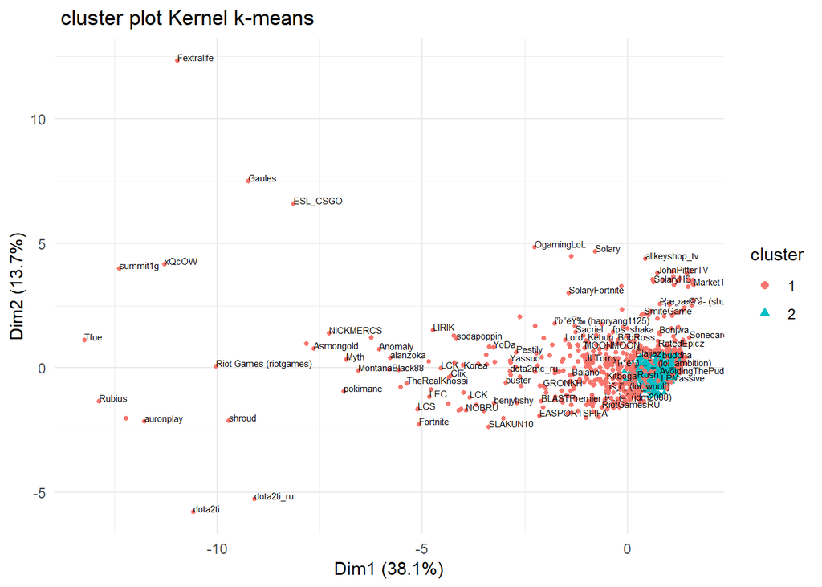

```r
object.ker = list(data = data.num, cluster = fit.ker@.Data)

c= fviz_cluster(object.ker, geom = c("point"), ellipse=F,pointsize=1, main =" cluster plot Kernel k-means") + theme_minimal()+geom_text(label=names,hjust=0,                           vjust=0,size=2,check_overlap = T)+scale_fill_brewer(palette="Paired");c
```

Later, this cluster will be compared with the previous ones. Before that, let’s make **hierarchical cluster** also.

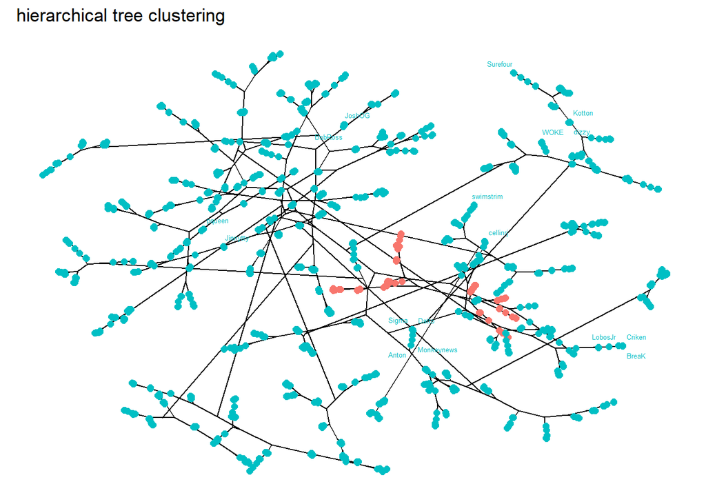

```r
dist = dist(scale(data.num), method = "euclidean")
hc = hclust(dist, method = "ward.D2")

hc$labels = names

d = fviz_dend(x = hc,
k = 2,
color_labels_by_k = TRUE,
cex = 0.4,
type = "phylogenic",
repel = TRUE)+
labs(title=" hierarchical tree clustering") +             theme(axis.text.x=element_blank(),axis.text.y=element_blank());d
```

*Note that there are too many names to be shown in the plot*

Lastly, let’s try PAM clustering.

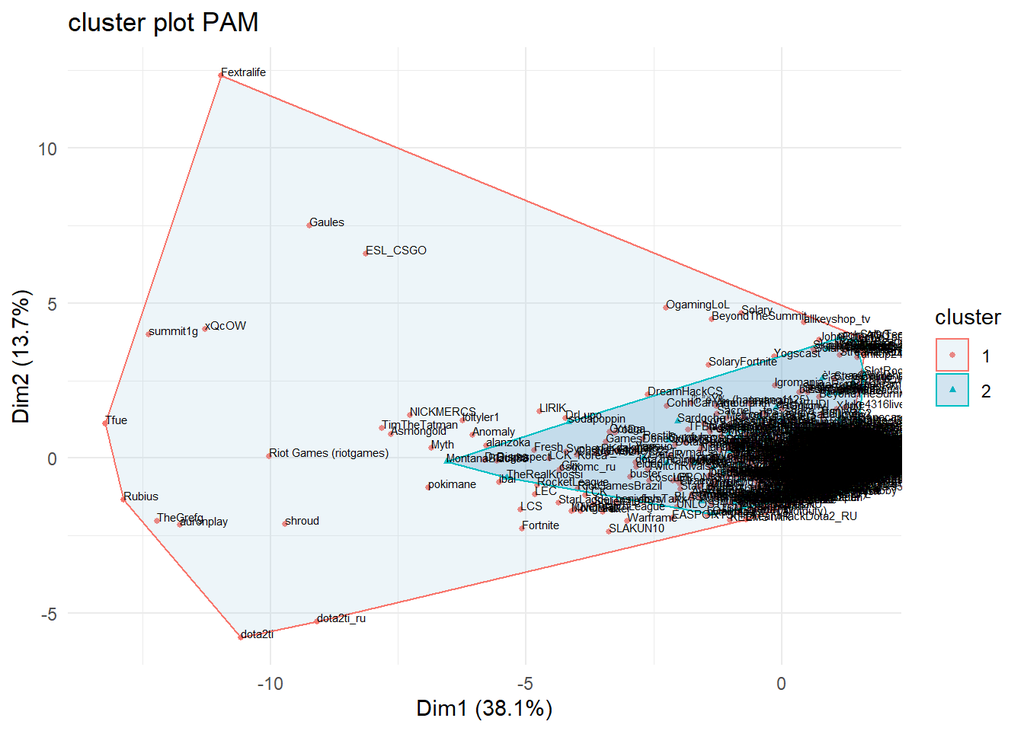

```r
fit.pam <- eclust(data.num, "pam", stand=TRUE, k=2, graph=F)

e=fviz_cluster(fit.pam, data = data.num, geom = c("point"), pointsize=1, main ="cluster plot PAM")+
theme_minimal()+geom_text(label=names,hjust=0,                      vjust=0,size=2,check_overlap =                                      F)+scale_fill_brewer(palette="Paired");e
```

## Conclusions  
With this, all possible methods have been done. Let’s recall all the different results:

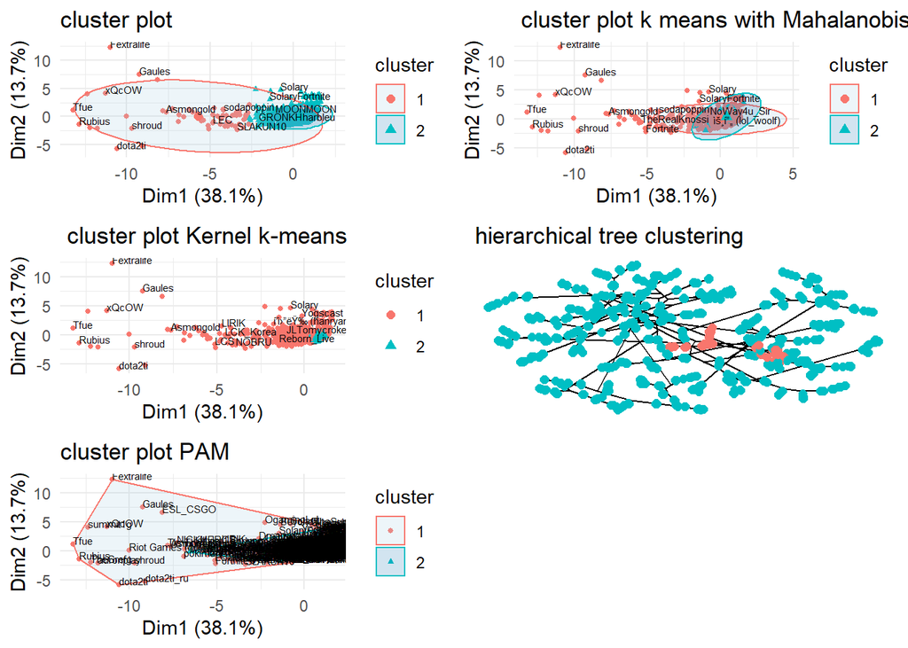

```r
grid.arrange(a,b,c,d,e,ncol=2)
```

What is more, it has been seen that clusters divide streamers depending on Watch.time.min, Followers and Viewers on its majority.

## Final conclusions of the project

Throughout this projects plots and unsupervised learning techniques have been used in order to get some conclusions about our initial question: **what makes a streamer great?** . And for answering that questions we had to determine which were the variables on our data set that could provide us some clues.

When it comes to **mature** and **partnered**, Principal Component Analysis gave our model a lot of noise and did not contribute to the definition of any model. For example, the mean of Average.Viewers of non-partnered was higher than the one of partnered, but the opposite happened with Followers. So for the final answer of our question, we must leave this variables apart.

Then, although **Language** variable couldn’t be analysed by any unsupervised learning, it must be remembered the huge amount of viewers and followers that English held on its own.

Furthermore, all the variables related with **followers and viewers** contributed to our model in a medium level: these contributed to one or another PCA and explained the variability of our model among 0.5 and 0.8. Despite this, Peak.viewers and Views.gained had a weaker impact, as they had a medium impact in a technique and a lower in the other. Special mention to Average.Viewers which explained 99% of the variability in Factor analysis. So our initial assumptions of the impact of these variables can be hold and the ones obtained in clustering too.

**Stream.time.min** provided a 79% of noise (uniqueness) and it should be forgotten.

And finishing, **Watch.Time.Min** is our “star” variable: in PCA, it contributed to both PCA highly and explained 99% of the variability in the model. Again, initial assumptions can be held along with the ones of the cluster.

Before finishing concluding, I think it would be very interesting to extend this data set with the number of bits (donations) that streamer had,the number of adds per hour used and the subscriptions in its channel in order to make a more specific analysis. Unfortunately, this information is not free and could not be used in this project.

And now, taking all this into account, all assumptions about Mature and Partnered should be forgotten. Summarizing the rest of assumptions:

- More viewers and more followers go hand by hand. The same happens with less viewers and followers.
- More viewer and followers mean a higher watch time of the streamer.
- A peak of viewers can lead to an increment of average viewers and as a consequence, of followers.